# Project part Total

:)

Author

Hanxi Chen, Hanying Xu, Xiaomiao Wang

Published

March 13, 2026

```r
library(tidyverse)
library(car)
library(dplyr)
library(survival)
library(survminer)
library(zoo) # na.locf

library(janitor)
library(skimr)

library(tableone)

library(tableone)
library(gtsummary)
```

## 1 Import and Cleaning

```r
METABRIC_RNA_Mutation <- read.csv("METABRIC_RNA_Mutation.csv")
```

```r
dat0 <- METABRIC_RNA_Mutation %>%
  as_tibble()

# rename variables
dat1 <- dat0 %>%
  transmute(
    patient_id,
    er_status,
    hormone_therapy,
    chemotherapy,
    os_months = overall_survival_months,
    os_event = overall_survival,

    age = age_at_diagnosis,
    tumor_size,
    nodes_positive = lymph_nodes_examined_positive,
    grade = neoplasm_histologic_grade,
    her2 = her2_status,
    pam50 = `pam50_._claudin.low_subtype`,
    tumor_stage,
    menopausal_state = inferred_menopausal_state,
    pr_status,
    surgery = type_of_breast_surgery,
    radio_therapy
  )

# cleaning variables
dat2 <- dat1 %>%
  mutate(
    across(where(is.character), ~na_if(.x, "")),
    across(c(er_status, hormone_therapy, chemotherapy,
             grade, her2, pam50, tumor_stage,
             menopausal_state, pr_status, surgery, radio_therapy), as.character),
    across(c(age, tumor_size, nodes_positive, os_months, os_event), as.numeric)
  )
```

```r
table(dat2$er_status, useNA = "ifany")
```

```
Negative Positive
     445     1459
```

```r
table(dat2$hormone_therapy, useNA = "ifany")
```

```
   0    1
 730 1174
```

```r
table(dat2$chemotherapy, useNA = "ifany")
```

```
   0    1
1508  396
```

```r
table(dat2$grade, useNA = "ifany")
```

```
   1    2    3 <NA>
 165  740  927   72
```

```r
table(dat2$her2, useNA = "ifany")
```

```
Negative Positive
    1668      236
```

```r
table(dat2$pam50, useNA = "ifany")
```

```
      Basal claudin-low        Her2        LumA        LumB          NC
        199         199         220         679         461           6
     Normal
        140
```

```r
table(dat2$tumor_stage, useNA = "ifany")
```

```
   0    1    2    3    4 <NA>
   4  475  800  115    9  501
```

```r
table(dat2$menopausal_state, useNA = "ifany")
```

```
Post  Pre
1493  411
```

```r
table(dat2$pr_status, useNA = "ifany")
```

```
Negative Positive
     895     1009
```

```r
table(dat2$surgery, useNA = "ifany")
```

```
BREAST CONSERVING        MASTECTOMY              <NA>
              755              1127                22
```

```r
table(dat2$radio_therapy, useNA = "ifany")
```

```
   0    1
 767 1137
```

```r
dat_table1 <- dat2 %>%
  filter(
    er_status == "Positive",
    hormone_therapy == 1
  ) %>%
  mutate(
    chemo = chemotherapy,
    trt_group = factor(
      chemo,
      levels = c(0, 1),
      labels = c("Hormone only", "Hormone + Chemo")
    )
  ) %>%
  filter(
    !is.na(chemo),
    !is.na(os_months),
    !is.na(os_event)
  )

nrow(dat0)
```

```
[1] 1904
```

```r
nrow(dat_table1)
```

```
[1] 1047
```

```r
table(dat_table1$trt_group, useNA = "ifany")
```

```
   Hormone only Hormone + Chemo
            924             123
```

```r
prop.table(table(dat_table1$trt_group))
```

```
   Hormone only Hormone + Chemo
      0.8825215       0.1174785
```

```r
vars_check <- c(
  "age", "tumor_size", "nodes_positive",
  "grade", "her2", "pam50", "tumor_stage",
  "menopausal_state", "pr_status",
  "surgery", "radio_therapy"
)

missing_by_group_long <- dat_table1 %>%
  group_by(trt_group) %>%
  summarise(
    across(all_of(vars_check), ~mean(is.na(.))*100)
  ) %>%
  pivot_longer(
    -trt_group,
    names_to = "variable",
    values_to = "pct_missing"
  )

missing_by_group_long
```

```
# A tibble: 22 × 3
   trt_group    variable         pct_missing
   <fct>        <chr>                  <dbl>
 1 Hormone only age                    0
 2 Hormone only tumor_size             0.758
 3 Hormone only nodes_positive         0
 4 Hormone only grade                  4.11
 5 Hormone only her2                   0
 6 Hormone only pam50                  0
 7 Hormone only tumor_stage           28.8
 8 Hormone only menopausal_state       0
 9 Hormone only pr_status              0
10 Hormone only surgery                0.541
# ℹ 12 more rows
```

## 2 Table 1: covariate distributions over Trt Groups

```r
# raw version
vars <- c(
  "age", "tumor_size", "nodes_positive",
  "grade", "her2", "pam50", "tumor_stage",
  "menopausal_state", "pr_status", "surgery", "radio_therapy"
)

factorVars <- c(
  "grade", "her2", "pam50", "tumor_stage",
  "menopausal_state", "pr_status", "surgery", "radio_therapy"
)

tab1 <- CreateTableOne(
  vars = vars,
  strata = "trt_group",
  data = dat_table1,
  factorVars = factorVars,
  includeNA = TRUE
)

print(
  tab1,
  showAllLevels = TRUE,
  quote = FALSE,
  noSpaces = TRUE,
  nonnormal = c("tumor_size", "nodes_positive")
)
```

```
                               Stratified by trt_group
                                level             Hormone only
  n                                               924
  age (mean (SD))                                 66.06 (10.90)
  tumor_size (median [IQR])                       23.00 [18.00, 30.00]
  nodes_positive (median [IQR])                   1.00 [0.00, 2.00]
  grade (%)                     1                 95 (10.3)
                                2                 418 (45.2)
                                3                 373 (40.4)
                                <NA>              38 (4.1)
  her2 (%)                      Negative          859 (93.0)
                                Positive          65 (7.0)
  pam50 (%)                     Basal             13 (1.4)
                                claudin-low       52 (5.6)
                                Her2              53 (5.7)
                                LumA              410 (44.4)
                                LumB              331 (35.8)
                                NC                4 (0.4)
                                Normal            61 (6.6)
  tumor_stage (%)               0                 1 (0.1)
                                1                 181 (19.6)
                                2                 422 (45.7)
                                3                 50 (5.4)
                                4                 4 (0.4)
                                <NA>              266 (28.8)
  menopausal_state (%)          Post              850 (92.0)
                                Pre               74 (8.0)
  pr_status (%)                 Negative          312 (33.8)
                                Positive          612 (66.2)
  surgery (%)                   BREAST CONSERVING 372 (40.3)
                                MASTECTOMY        547 (59.2)
                                <NA>              5 (0.5)
  radio_therapy (%)             0                 375 (40.6)
                                1                 549 (59.4)
                               Stratified by trt_group
                                Hormone + Chemo      p      test
  n                             123
  age (mean (SD))               53.57 (10.72)        <0.001
  tumor_size (median [IQR])     26.00 [21.00, 38.50] <0.001 nonnorm
  nodes_positive (median [IQR]) 2.00 [1.00, 6.00]    <0.001 nonnorm
```

[output cut: 13 more lines]

```
  tumor_stage (%)               0 (0.0)              <0.001
                                4 (3.3)
                                90 (73.2)
                                13 (10.6)
                                3 (2.4)
                                13 (10.6)
  menopausal_state (%)          76 (61.8)            <0.001
                                47 (38.2)
  pr_status (%)                 44 (35.8)            0.734
                                79 (64.2)
  surgery (%)                   40 (32.5)            0.113
                                81 (65.9)
                                2 (1.6)
  radio_therapy (%)             22 (17.9)            <0.001
                                101 (82.1)
```

##### 2.0.0.1 numeric table

These findings suggest that treatment assignment was strongly associated with baseline risk factors.

```r
summary_table <- function(data, vars, group_var = "trt_group") {

  out <- lapply(vars, function(v) {
    x <- data[[v]]
    g <- data[[group_var]]

    g1 <- as.numeric(x[g == "Hormone only"])
    g2 <- as.numeric(x[g == "Hormone + Chemo"])

    ttest <- t.test(g1, g2)

    mean1 <- mean(g1, na.rm = TRUE)
    sd1 <- sd(g1, na.rm = TRUE)
    mean2 <- mean(g2, na.rm = TRUE)
    sd2 <- sd(g2, na.rm = TRUE)
    smd <- (mean2 - mean1) / sqrt((sd1^2 + sd2^2) / 2)

    data.frame(
      Variable = v,
      Mean_Group1 = mean1,
      SD_Group1 = sd1,
      Mean_Group2 = mean2,
      SD_Group2 = sd2,
      t_value = as.numeric(ttest$statistic),
      p_value = ttest$p.value,
      SMD = smd
    )
  })

  dplyr::bind_rows(out)
}

cont_vars <- c("age", "tumor_size", "nodes_positive")

cont_table <- summary_table(dat_table1, cont_vars) |>
  dplyr::mutate(
    across(where(is.numeric), ~round(.x, 3))
  )

print(cont_table)
```

```
        Variable Mean_Group1 SD_Group1 Mean_Group2 SD_Group2 t_value p_value
1            age      66.059    10.903      53.567    10.719  12.118   0.000
2     tumor_size      25.979    12.859      32.039    19.684  -3.308   0.001
3 nodes_positive       1.979     3.693       4.707     6.180  -4.783   0.000
     SMD
1 -1.156
2  0.365
3  0.536
```

##### 2.0.0.2 categorical table

```r
categorical_table <- function(data, vars, group_var = "trt_group") {

  out <- lapply(vars, function(v) {
    x <- data[[v]]
    g <- data[[group_var]]

    # convert to character and keep missing as a level
    x_chr <- as.character(x)
    x_chr[is.na(x_chr)] <- "Missing"

    g_chr <- as.character(g)

    tab <- table(x_chr, g_chr)
    prop <- prop.table(tab, margin = 2) * 100

    # choose test automatically
    test <- if (any(tab < 5)) fisher.test(tab) else chisq.test(tab)

    stat_value <- if ("statistic" %in% names(test)) as.numeric(test$statistic) else NA_real_
    p_value <- test$p.value

    # avoid errors from missing group columns
    n1 <- if ("Hormone only" %in% colnames(tab)) tab[, "Hormone only"] else rep(0, nrow(tab))
    n2 <- if ("Hormone + Chemo" %in% colnames(tab)) tab[, "Hormone + Chemo"] else rep(0, nrow(tab))

    p1 <- if ("Hormone only" %in% colnames(prop)) prop[, "Hormone only"] else rep(0, nrow(prop))
    p2 <- if ("Hormone + Chemo" %in% colnames(prop)) prop[, "Hormone + Chemo"] else rep(0, nrow(prop))

    df <- data.frame(
      Variable = v,
      Level = rownames(tab),
      n_Group1 = as.numeric(n1),
      pct_Group1 = as.numeric(p1),
      n_Group2 = as.numeric(n2),
      pct_Group2 = as.numeric(p2),
      statistic = NA_real_,
      p_value = NA_real_,
      stringsAsFactors = FALSE
    )

    # put test results on the first row only
    df$statistic[1] <- stat_value
    df$p_value[1] <- p_value

    df
  })

  dplyr::bind_rows(out)
}

cat_vars <- c(
  "grade",
  "her2",
  "pam50",
  "tumor_stage",
  "menopausal_state",
  "pr_status",
  "surgery",
  "radio_therapy"
)

cat_table <- categorical_table(dat_table1, cat_vars) |>
  dplyr::mutate(
    dplyr::across(where(is.numeric), ~round(.x, 3))
  )

print(cat_table)
```

```
           Variable             Level n_Group1 pct_Group1 n_Group2 pct_Group2
1             grade                 1       95     10.281        7      5.691
2             grade                 2      418     45.238       42     34.146
3             grade                 3      373     40.368       72     58.537
4             grade           Missing       38      4.113        2      1.626
5              her2          Negative      859     92.965      109     88.618
6              her2          Positive       65      7.035       14     11.382
7             pam50             Basal       13      1.407        1      0.813
8             pam50       claudin-low       52      5.628       10      8.130
9             pam50              Her2       53      5.736        6      4.878
10            pam50              LumA      410     44.372       51     41.463
11            pam50              LumB      331     35.823       38     30.894
12            pam50                NC        4      0.433        0      0.000
13            pam50            Normal       61      6.602       17     13.821
14      tumor_stage                 0        1      0.108        0      0.000
```

[output cut: 43 more lines]

### 2.1 RMST

```r
ps_vars <- c(
  "chemo",
  "trt_group",
  "os_months",
  "os_event",
  "age",
  "tumor_size",
  "nodes_positive",
  "grade",
  "pam50"
)

dat_km <- dat_table1 %>%
  select(all_of(ps_vars)) %>%
  filter(
    !is.na(chemo),
    !is.na(os_months),
    !is.na(os_event),
    !is.na(age),
    !is.na(tumor_size),
    !is.na(nodes_positive),
    !is.na(grade),
    !is.na(pam50)
  ) %>%
  mutate(
    chemo = as.numeric(chemo)
  )
```

```r
library(survRM2)
rmst_res <- rmst2(
  time   = dat_km$os_months,
  status = dat_km$os_event,
  arm    = dat_km$chemo,
  tau    = 100
)
rmst_res
```

```
The truncation time: tau = 100  was specified.

Restricted Mean Survival Time (RMST) by arm
               Est.    se lower .95 upper .95
RMST (arm=1) 95.226 1.276    92.725    97.726
RMST (arm=0) 95.518 0.517    94.505    96.532


Restricted Mean Time Lost (RMTL) by arm
              Est.    se lower .95 upper .95
RMTL (arm=1) 4.774 1.276     2.274     7.275
RMTL (arm=0) 4.482 0.517     3.468     5.495


Between-group contrast
                       Est. lower .95 upper .95     p
RMST (arm=1)-(arm=0) -0.293    -2.991     2.406 0.832
RMST (arm=1)/(arm=0)  0.997     0.969     1.026 0.832
RMTL (arm=1)/(arm=0)  1.065     0.602     1.885 0.828
```

## 3 Crude KM & Log-rank test: unadjusted association

### 3.1 KM curve

The Kaplan–Meier estimator was used to estimate the survival function for each treatment group. The log-rank test was used to compare the survival distributions between treatment groups.

```r
library(survival)
library(survminer)
```

```r
ps_vars <- c(
  "chemo",
  "trt_group",
  "os_months",
  "os_event",
  "age",
  "tumor_size",
  "nodes_positive",
  "grade",
  "pam50"
)

dat_km <- dat_table1 %>%
  select(all_of(ps_vars)) %>%
  filter(
    !is.na(chemo),
    !is.na(os_months),
    !is.na(os_event),
    !is.na(age),
    !is.na(tumor_size),
    !is.na(nodes_positive),
    !is.na(grade),
    !is.na(pam50)
  ) %>%
  mutate(
    chemo = as.numeric(chemo)
  )



table(dat_km$trt_group)
```

```
   Hormone only Hormone + Chemo
            880             120
```

```r
prop.table(table(dat_km$trt_group))
```

```
   Hormone only Hormone + Chemo
           0.88            0.12
```

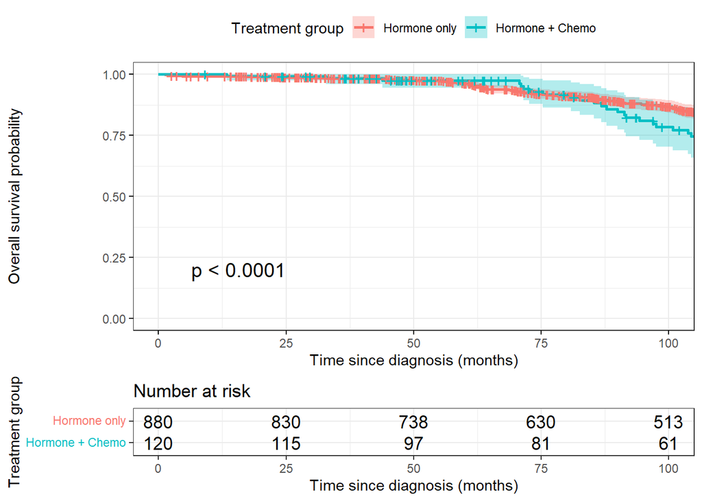

```r
tau <- 100

fit_km <- survfit(
  Surv(os_months, os_event) ~ trt_group,
  data = dat_km
)

ggsurvplot(
  fit_km,
  data = dat_km,
  risk.table = TRUE,
  pval = TRUE,
  conf.int = TRUE,
  xlab = "Time since diagnosis (months)",
  ylab = "Overall survival probability",
  legend.title = "Treatment group",
  legend.labs = c("Hormone only", "Hormone + Chemo"),
  xlim = c(0, tau),
  break.time.by = 25,
  ggtheme = theme_bw()
)
```

```r
summary(fit_km, times = tau)
```

```
Call: survfit(formula = Surv(os_months, os_event) ~ trt_group, data = dat_km)

                trt_group=Hormone only
        time       n.risk      n.event     survival      std.err lower 95% CI
    100.0000     513.0000      94.0000       0.8665       0.0129       0.8416
upper 95% CI
      0.8923

                trt_group=Hormone + Chemo
        time       n.risk      n.event     survival      std.err lower 95% CI
    100.0000      61.0000      19.0000       0.7843       0.0443       0.7021
upper 95% CI
      0.8761
```

The crude Kaplan-Meier curves suggested worse survival in the chemotherapy group. However, this comparison is unadjusted and may reflect baseline differences in disease severity rather than treatment effect.

```r
survdiff(Surv(os_months, os_event) ~ trt_group, data = dat_km)
```

```
Call:
survdiff(formula = Surv(os_months, os_event) ~ trt_group, data = dat_km)

                            N Observed Expected (O-E)^2/E (O-E)^2/V
trt_group=Hormone only    880      354    392.8      3.82        57
trt_group=Hormone + Chemo 120       68     29.2     51.37        57

 Chisq= 57  on 1 degrees of freedom, p= 4e-14
```

## 4 Weighted KM and Log-rank Test

### 4.1 calculate propensity score

set up dataset for Propensity score models:

```r
ps_vars <- c(
  "chemo",
  "trt_group",
  "os_months",
  "os_event",
  "age",
  "tumor_size",
  "nodes_positive",
  "grade",
  "pam50"
)

dat_ps <- dat_table1 %>%
  select(all_of(ps_vars)) %>%
  mutate(
    pam50_grp = case_when(
      pam50 %in% c("LumA", "LumB") ~ pam50,
      TRUE ~ "Other"
    )
  ) %>%
  filter(
    !is.na(chemo),
    !is.na(os_months),
    !is.na(os_event),
    !is.na(age),
    !is.na(tumor_size),
    !is.na(nodes_positive),
    !is.na(grade),
    !is.na(pam50_grp)
  ) %>%
  mutate(
    chemo = as.numeric(chemo),
    grade = factor(grade),
    pam50_grp = factor(pam50_grp, levels = c("LumA", "LumB", "Other"))
  )


nrow(dat_table1)
```

```
[1] 1047
```

```r
nrow(dat_ps)
```

```
[1] 1000
```

```r
table(dat_ps$trt_group)
```

```
   Hormone only Hormone + Chemo
            880             120
```

```r
prop.table(table(dat_ps$trt_group))
```

```
   Hormone only Hormone + Chemo
           0.88            0.12
```

### 4.2 fit propensity score model and calculate IPTW

A logistic regression model was used to estimate the propensity score for receiving chemotherapy.

```r
ps_fit <- glm(
  chemo ~ age + tumor_size + nodes_positive + grade + pam50_grp,
  data = dat_ps,
  family = binomial()
)

summary(ps_fit)
```

```
Call:
glm(formula = chemo ~ age + tumor_size + nodes_positive + grade +
    pam50_grp, family = binomial(), data = dat_ps)

Coefficients:
                Estimate Std. Error z value Pr(>|z|)
(Intercept)     2.689081   0.745980   3.605 0.000312 ***
age            -0.107466   0.010868  -9.889  < 2e-16 ***
tumor_size      0.024736   0.007091   3.488 0.000486 ***
nodes_positive  0.113761   0.022529   5.050 4.43e-07 ***
grade2          0.510368   0.493025   1.035 0.300587
grade3          1.125093   0.489501   2.298 0.021536 *
pam50_grpLumB  -0.319817   0.274153  -1.167 0.243385
pam50_grpOther  0.086350   0.280779   0.308 0.758435
---
Signif. codes:  0 '***' 0.001 '**' 0.01 '*' 0.05 '.' 0.1 ' ' 1

(Dispersion parameter for binomial family taken to be 1)

    Null deviance: 733.85  on 999  degrees of freedom
Residual deviance: 544.77  on 992  degrees of freedom
AIC: 560.77

Number of Fisher Scoring iterations: 6
```

calculate stabilized IPTW:

```r
dat_ps <- dat_ps %>%
  mutate(
    ps = predict(ps_fit, type = "response"),
    p_treat = mean(chemo == 1),
    sw = if_else(
      chemo == 1,
      p_treat / ps,
      (1 - p_treat) / (1 - ps)
    ),
    iptw = if_else(
      chemo == 1,
      1 / ps,
      1 / (1 - ps)
    )
  )
```

### 4.3 check overlap

```r
dat_ps %>%
  group_by(trt_group) %>%
  summarise(
    n = n(),
    min_ps = min(ps),
    q1_ps = quantile(ps, 0.25),
    median_ps = median(ps),
    mean_ps = mean(ps),
    q3_ps = quantile(ps, 0.75),
    max_ps = max(ps)
  )
```

```
# A tibble: 2 × 8
  trt_group           n  min_ps  q1_ps median_ps mean_ps q3_ps max_ps
  <fct>           <int>   <dbl>  <dbl>     <dbl>   <dbl> <dbl>  <dbl>
1 Hormone only      880 0.00185 0.0213    0.0485  0.0908 0.108  0.922
2 Hormone + Chemo   120 0.00583 0.135     0.277   0.334  0.468  0.919
```

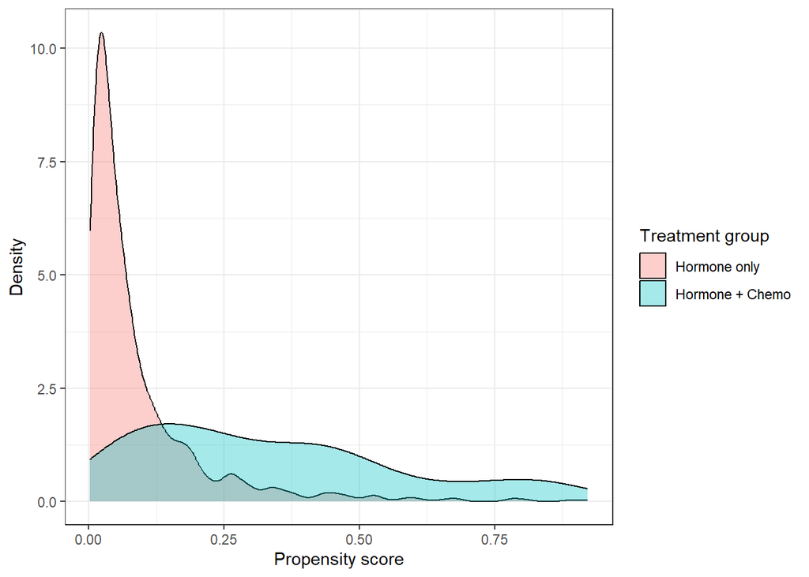

```r
ggplot(dat_ps, aes(x = ps, fill = trt_group)) +
  geom_density(alpha = 0.35) +
  labs(
    x = "Propensity score",
    y = "Density",
    fill = "Treatment group"
  ) +
  theme_bw()
```

```r
ps_range <- dat_ps %>%
  group_by(trt_group) %>%
  summarise(
    min_ps = min(ps),
    max_ps = max(ps)
  )

ps_range
```

```
# A tibble: 2 × 3
  trt_group        min_ps max_ps
  <fct>             <dbl>  <dbl>
1 Hormone only    0.00185  0.922
2 Hormone + Chemo 0.00583  0.919
```

check weight distribution:

```r
summary(dat_ps$sw)
```

```
   Min. 1st Qu.  Median    Mean 3rd Qu.    Max.
 0.1306  0.8954  0.9196  1.0265  0.9851 20.5983
```

```r
quantile(dat_ps$sw, probs = c(0, 0.01, 0.05, 0.25, 0.5, 0.75, 0.95, 0.99, 1))
```

```
        0%         1%         5%        25%        50%        75%        95%
 0.1305521  0.1516082  0.3270123  0.8954434  0.9196420  0.9850688  1.4409868
       99%       100%
 3.0403381 20.5982836
```

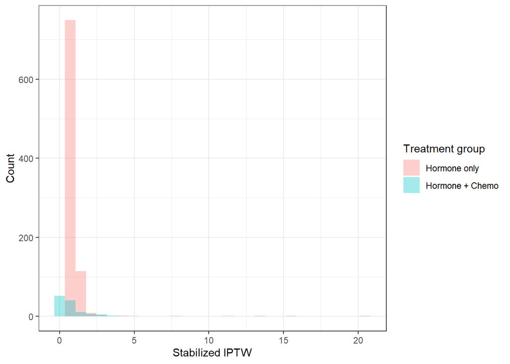

```r
ggplot(dat_ps, aes(x = sw, fill = trt_group)) +
  geom_histogram(position = "identity", alpha = 0.35, bins = 30) +
  labs(
    x = "Stabilized IPTW",
    y = "Count",
    fill = "Treatment group"
  ) +
  theme_bw()
```

balance before weighting:

```r
vars_balance <- c(
  "age",
  "tumor_size",
  "nodes_positive",
  "grade",
  "pam50_grp"
)

factorVars_balance <- c(
  "grade",
  "pam50_grp"
)

tab_unw <- CreateTableOne(
  vars = vars_balance,
  strata = "trt_group",
  data = dat_ps,
  factorVars = factorVars_balance,
  includeNA = TRUE,
  smd = TRUE
)

print(
  tab_unw,
  showAllLevels = TRUE,
  quote = FALSE,
  noSpaces = TRUE,
  smd = TRUE,
  nonnormal = c("tumor_size", "nodes_positive")
)
```

```
                               Stratified by trt_group
                                level Hormone only         Hormone + Chemo
  n                                   880                  120
  age (mean (SD))                     65.87 (10.88)        53.59 (10.82)
  tumor_size (median [IQR])           23.00 [18.00, 30.00] 26.00 [21.00, 37.50]
  nodes_positive (median [IQR])       1.00 [0.00, 2.00]    2.00 [1.00, 6.00]
  grade (%)                     1     95 (10.8)            6 (5.0)
                                2     416 (47.3)           42 (35.0)
                                3     369 (41.9)           72 (60.0)
  pam50_grp (%)                 LumA  389 (44.2)           51 (42.5)
                                LumB  319 (36.2)           36 (30.0)
                                Other 172 (19.5)           33 (27.5)
                               Stratified by trt_group
                                p      test    SMD
  n
  age (mean (SD))               <0.001         1.132
  tumor_size (median [IQR])     <0.001 nonnorm 0.365
  nodes_positive (median [IQR]) <0.001 nonnorm 0.555
  grade (%)                     0.001          0.385


  pam50_grp (%)                 0.106          0.199
```

balance after weighting:

```r
library(survey)
design_sw <- svydesign(
  ids = ~1,
  weights = ~sw,
  data = dat_ps
)

tab_w <- svyCreateTableOne(
  vars = vars_balance,
  strata = "trt_group",
  data = design_sw,
  factorVars = factorVars_balance,
  includeNA = TRUE,
  smd = TRUE
)

print(
  tab_w,
  showAllLevels = TRUE,
  quote = FALSE,
  noSpaces = TRUE,
  smd = TRUE,
  nonnormal = c("tumor_size", "nodes_positive")
)
```

```
                               Stratified by trt_group
                                level Hormone only         Hormone + Chemo
  n                                   893.08               133.38
  age (mean (SD))                     64.17 (11.94)        67.90 (13.71)
  tumor_size (median [IQR])           24.00 [18.00, 30.00] 25.00 [18.00, 26.00]
  nodes_positive (median [IQR])       1.00 [0.00, 2.00]    1.00 [1.00, 2.00]
  grade (%)                     1     89.7 (10.0)          22.4 (16.8)
                                2     402.0 (45.0)         55.4 (41.5)
                                3     401.3 (44.9)         55.6 (41.7)
  pam50_grp (%)                 LumA  387.9 (43.4)         75.8 (56.8)
                                LumB  325.3 (36.4)         36.2 (27.2)
                                Other 179.8 (20.1)         21.4 (16.0)
                               Stratified by trt_group
                                p      test    SMD
  n
  age (mean (SD))               0.278          0.290
  tumor_size (median [IQR])     0.939  nonnorm 0.078
  nodes_positive (median [IQR]) <0.001 nonnorm 0.052
  grade (%)                     0.683          0.198


  pam50_grp (%)                 0.294          0.271
```

### 4.4 compare SMD before and after weighting

SMD < 0.1 → ideal SMD < 0.2 → acceptable SMD > 0.2 → imbalance

```r
smd_unw <- ExtractSmd(tab_unw)
smd_w <- ExtractSmd(tab_w)

smd_compare <- data.frame(
  variable = vars_balance,
  smd_unweighted = as.numeric(smd_unw),
  smd_weighted = as.numeric(smd_w)
) %>%
  arrange(desc(smd_unweighted))

smd_compare
```

```
        variable smd_unweighted smd_weighted
1            age      1.1321405   0.28984004
2 nodes_positive      0.5547832   0.05200370
3          grade      0.3853747   0.19827412
4     tumor_size      0.3650600   0.07822265
5      pam50_grp      0.1993822   0.27077692
```

```r
smd_compare %>%
  mutate(
    imbalance_unweighted = abs(smd_unweighted) > 0.1,
    imbalance_weighted = abs(smd_weighted) > 0.1
  )
```

```
        variable smd_unweighted smd_weighted imbalance_unweighted
1            age      1.1321405   0.28984004                 TRUE
2 nodes_positive      0.5547832   0.05200370                 TRUE
3          grade      0.3853747   0.19827412                 TRUE
4     tumor_size      0.3650600   0.07822265                 TRUE
5      pam50_grp      0.1993822   0.27077692                 TRUE
  imbalance_weighted
1               TRUE
2              FALSE
3               TRUE
4              FALSE
5               TRUE
```

We estimated a propensity score for receiving chemotherapy using baseline clinical covariates age, tumor size, number of positive lymph nodes, histologic grade, and PAM50 subtype, then constructed stabilized inverse probability of treatment weights. The propensity score distributions showed adequate overlap between treatment groups, although the chemotherapy group had generally larger scores, consistent with confounding by indication. The stabilized weights were overall well behaved, with mean close to 1 and only a few large values, suggesting that the weighted analysis should be reasonably stable. Covariate balance improved meaningfully after weighting, especially for nodal involvement and tumor size, while some residual imbalance remained for age, grade, and PAM50. Overall, these diagnostics suggest that IPTW is appropriate as an adjusted survival comparison, while residual confounding should still be acknowledged.

### 4.5 IPTW weighted KM

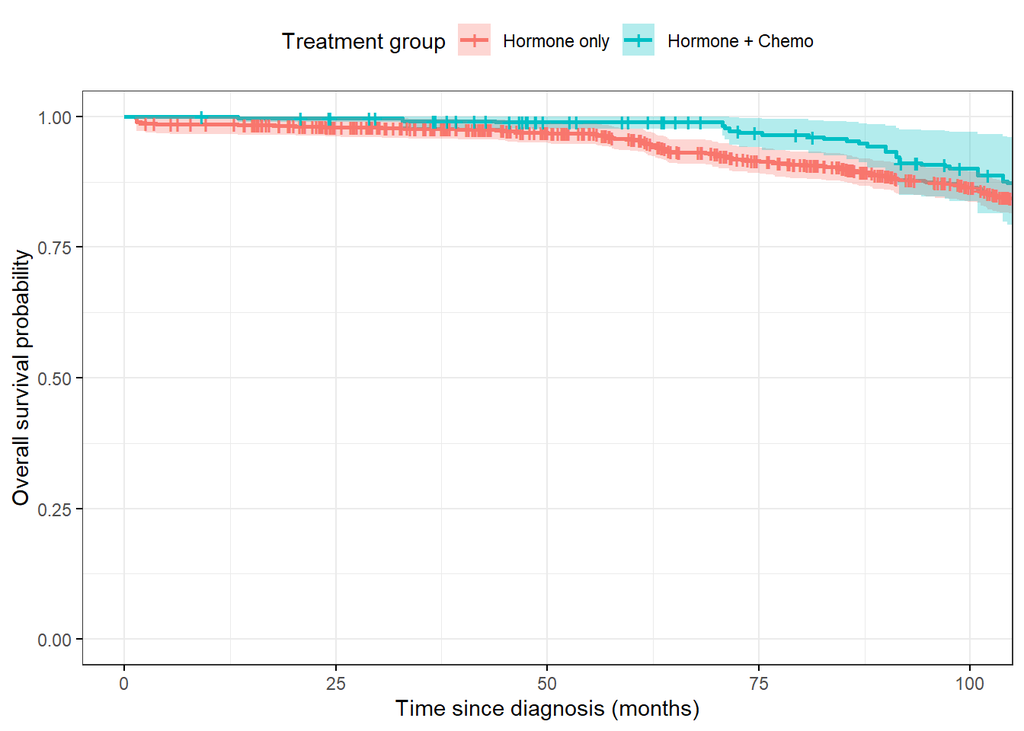

```r
# fit weighted km curves
fit_km_w <- survfit(
  Surv(os_months, os_event) ~ trt_group,
  data = dat_ps,
  weights = sw
)

ggsurvplot(
  fit_km_w,
  data = dat_ps,
  conf.int = TRUE,
  xlab = "Time since diagnosis (months)",
  ylab = "Overall survival probability",
  legend.title = "Treatment group",
  legend.labs = c("Hormone only", "Hormone + Chemo"),
  xlim = c(0, tau),
  break.time.by = 25,
  ggtheme = theme_bw()
)
```

```r
summary(fit_km_w, times = tau)
```

```
Call: survfit(formula = Surv(os_months, os_event) ~ trt_group, data = dat_ps,
    weights = sw)

                trt_group=Hormone only
        time       n.risk      n.event     survival      std.err lower 95% CI
    100.0000     522.5511      97.8985       0.8650       0.0148       0.8364
upper 95% CI
      0.8946

                trt_group=Hormone + Chemo
        time       n.risk      n.event     survival      std.err lower 95% CI
    100.0000      56.3584       7.2110       0.9015       0.0337       0.8377
upper 95% CI
      0.9701
```

```r
kmw_150 <- summary(fit_km_w, times = tau)

data.frame(
  trt_group = kmw_150$strata,
  time = kmw_150$time,
  surv = kmw_150$surv,
  lower = kmw_150$lower,
  upper = kmw_150$upper
)
```

```
                  trt_group time      surv     lower     upper
1    trt_group=Hormone only  100 0.8650449 0.8364480 0.8946194
2 trt_group=Hormone + Chemo  100 0.9014609 0.8376997 0.9700753
```

### 4.6 IPTW weighted logrank

```r
design_sw <- svydesign(
  ids = ~1,
  weights = ~sw,
  data = dat_ps
)
```

```r
library(survey)

fit_wlr <- svylogrank(
  Surv(os_months, os_event) ~ trt_group,
  design = design_sw
)

fit_wlr
```

```
[[1]]
        score
[1,] 16.79338 6.125427 2.741585 0.006114355

[[2]]
      Chisq           p
7.516287863 0.006114355

attr(,"class")
[1] "svylogrank"
```

### 4.7 IPTW weighted cox

```r
dat_wcox <- dat_table1 %>%
  select(
    patient_id,
    chemo,
    trt_group,
    os_months,
    os_event,
    age,
    tumor_size,
    nodes_positive,
    grade,
    pam50
  ) %>%
  mutate(
    pam50_grp = case_when(
      pam50 %in% c("LumA", "LumB") ~ pam50,
      TRUE ~ "Other"
    )
  ) %>%
  filter(
    !is.na(patient_id),
    !is.na(chemo),
    !is.na(os_months),
    !is.na(os_event),
    !is.na(age),
    !is.na(tumor_size),
    !is.na(nodes_positive),
    !is.na(grade),
    !is.na(pam50_grp)
  ) %>%
  mutate(
    chemo = as.numeric(chemo),
    grade = factor(grade),
    pam50_grp = factor(pam50_grp, levels = c("LumA", "LumB", "Other"))
  )
```

```r
ps_fit <- glm(
  chemo ~ age + tumor_size + nodes_positive + grade + pam50_grp,
  data = dat_wcox,
  family = binomial()
)

dat_wcox <- dat_wcox %>%
  mutate(
    ps = predict(ps_fit, type = "response"),
    p_treat = mean(chemo == 1),
    sw = if_else(
      chemo == 1,
      p_treat / ps,
      (1 - p_treat) / (1 - ps)
    )
  )
```

#### 4.7.1 weighted cox without time-dependent chemotherapy:

```r
cox_w <- coxph(
  Surv(os_months, os_event) ~
    chemo +
    age +
    tumor_size +
    nodes_positive +
    grade +
    pam50_grp,
  data = dat_wcox,
  weights = sw,
  ties = "breslow",
  robust = TRUE,
  id = patient_id
)

summary(cox_w)
```

```
Call:
coxph(formula = Surv(os_months, os_event) ~ chemo + age + tumor_size +
    nodes_positive + grade + pam50_grp, data = dat_wcox, weights = sw,
    ties = "breslow", robust = TRUE, id = patient_id)

  n= 1000, number of events= 422

                    coef exp(coef)  se(coef) robust se      z Pr(>|z|)
chemo           0.558749  1.748484  0.175773  0.217748  2.566   0.0103 *
age            -0.017621  0.982533  0.004692  0.007653 -2.302   0.0213 *
tumor_size     -0.008927  0.991113  0.004355  0.005171 -1.726   0.0843 .
nodes_positive -0.015568  0.984553  0.011852  0.023293 -0.668   0.5039
grade2         -0.139389  0.869890  0.151194  0.184016 -0.757   0.4488
grade3         -0.457517  0.632853  0.161070  0.182473 -2.507   0.0122 *
pam50_grpLumB   0.200310  1.221781  0.121678  0.133011  1.506   0.1321
pam50_grpOther  0.185916  1.204321  0.132536  0.147263  1.262   0.2068
---
Signif. codes:  0 '***' 0.001 '**' 0.01 '*' 0.05 '.' 0.1 ' ' 1

               exp(coef) exp(-coef) lower .95 upper .95
chemo             1.7485     0.5719    1.1411    2.6792
age               0.9825     1.0178    0.9679    0.9974
tumor_size        0.9911     1.0090    0.9811    1.0012
nodes_positive    0.9846     1.0157    0.9406    1.0305
grade2            0.8699     1.1496    0.6065    1.2477
grade3            0.6329     1.5801    0.4426    0.9049
pam50_grpLumB     1.2218     0.8185    0.9414    1.5857
pam50_grpOther    1.2043     0.8303    0.9024    1.6073

Concordance= 0.592  (se = 0.02 )
Likelihood ratio test= 44.79  on 8 df,   p=4e-07
Wald test            = 40.8  on 8 df,   p=2e-06
Score (logrank) test = 46.52  on 8 df,   p=2e-07,   Robust = 31.27  p=1e-04

  (Note: the likelihood ratio and score tests assume independence of
     observations within a cluster, the Wald and robust score tests do not).
```

```r
ph_test_w <- cox.zph(cox_w)
ph_test_w
```

```
                chisq df       p
chemo          36.132  1 1.8e-09
age             0.187  1    0.67
tumor_size      0.619  1    0.43
nodes_positive  2.058  1    0.15
grade           1.519  2    0.47
pam50_grp       0.431  2    0.81
GLOBAL         42.273  8 1.2e-06
```

```r
event.times <- sort(unique(dat_wcox$os_months[dat_wcox$os_event == 1]))
event.times <- event.times[-1]

dat_split_w <- survSplit(
  data = dat_wcox,
  cut = event.times,
  end = "os_months",
  start = "t0",
  event = "os_event"
)
```

```r
dat_split_w <- dat_split_w %>%
  mutate(
    chemo_t = chemo * log(os_months)
  )
```

#### 4.7.2 weighted cox with time-dependent chemotherapy

```r
cox_w_td <- coxph(
  Surv(t0, os_months, os_event) ~
    chemo +
    chemo_t +
    age +
    tumor_size +
    nodes_positive +
    grade +
    pam50_grp,
  data = dat_split_w,
  weights = sw,
  ties = "breslow",
  robust = TRUE,
  id = patient_id
)

summary(cox_w_td)
```

```
Call:
coxph(formula = Surv(t0, os_months, os_event) ~ chemo + chemo_t +
    age + tumor_size + nodes_positive + grade + pam50_grp, data = dat_split_w,
    weights = sw, ties = "breslow", robust = TRUE, id = patient_id)

  n= 162869, number of events= 422

                     coef  exp(coef)   se(coef)  robust se      z Pr(>|z|)
chemo          -1.090e+01  1.842e-05  2.980e+00  3.426e+00 -3.183 0.001460 **
chemo_t         2.472e+00  1.185e+01  6.229e-01  7.023e-01  3.520 0.000431 ***
age            -1.616e-02  9.840e-01  4.744e-03  7.635e-03 -2.116 0.034328 *
tumor_size     -9.009e-03  9.910e-01  4.338e-03  5.106e-03 -1.764 0.077684 .
nodes_positive -1.595e-02  9.842e-01  1.204e-02  2.345e-02 -0.680 0.496493
grade2         -1.738e-01  8.404e-01  1.516e-01  1.795e-01 -0.968 0.332956
grade3         -4.817e-01  6.177e-01  1.609e-01  1.793e-01 -2.687 0.007204 **
pam50_grpLumB   1.806e-01  1.198e+00  1.215e-01  1.328e-01  1.359 0.174077
pam50_grpOther  1.845e-01  1.203e+00  1.326e-01  1.454e-01  1.269 0.204365
---
Signif. codes:  0 '***' 0.001 '**' 0.01 '*' 0.05 '.' 0.1 ' ' 1

               exp(coef) exp(-coef) lower .95 upper .95
chemo          1.842e-05  5.429e+04 2.235e-08   0.01517
chemo_t        1.185e+01  8.438e-02 2.992e+00  46.94353
age            9.840e-01  1.016e+00 9.694e-01   0.99881
tumor_size     9.910e-01  1.009e+00 9.812e-01   1.00100
nodes_positive 9.842e-01  1.016e+00 9.400e-01   1.03047
grade2         8.404e-01  1.190e+00 5.911e-01   1.19491
grade3         6.177e-01  1.619e+00 4.347e-01   0.87776
pam50_grpLumB  1.198e+00  8.348e-01 9.233e-01   1.55417
pam50_grpOther 1.203e+00  8.315e-01 9.045e-01   1.59916

Concordance= 0.615  (se = 0.019 )
Likelihood ratio test= 72.21  on 9 df,   p=6e-12
Wald test            = 78.93  on 9 df,   p=3e-13
Score (logrank) test = 64.47  on 9 df,   p=2e-10,   Robust = 36.4  p=3e-05

  (Note: the likelihood ratio and score tests assume independence of
     observations within a cluster, the Wald and robust score tests do not).
```

#### 4.7.3 clinical-only crude Cox

```r
# set up data for clinical-only crude cox
dat_ccox <- dat_table1 %>%
  select(
    patient_id,
    chemo,
    trt_group,
    os_months,
    os_event,
    age,
    tumor_size,
    nodes_positive,
    grade,
    pam50
  ) %>%
  mutate(
    pam50_grp = case_when(
      pam50 %in% c("LumA", "LumB") ~ pam50,
      TRUE ~ "Other"
    )
  ) %>%
  filter(
    !is.na(patient_id),
    !is.na(chemo),
    !is.na(os_months),
    !is.na(os_event),
    !is.na(age),
    !is.na(tumor_size),
    !is.na(nodes_positive),
    !is.na(grade),
    !is.na(pam50_grp)
  ) %>%
  mutate(
    chemo = factor(
      as.numeric(chemo),
      levels = c(0, 1),
      labels = c("Hormone only", "Hormone + Chemo")
    ),
    chemo_num = as.numeric(chemo == "Hormone + Chemo"),
    grade = factor(grade),
    pam50_grp = factor(pam50_grp, levels = c("LumA", "LumB", "Other"))
  )

nrow(dat_ccox)
```

```
[1] 1000
```

```r
table(dat_ccox$chemo, useNA = "ifany")
```

```
   Hormone only Hormone + Chemo
            880             120
```

```r
table(dat_ccox$grade, useNA = "ifany")
```

```
  1   2   3
101 458 441
```

```r
table(dat_ccox$pam50_grp, useNA = "ifany")
```

```
 LumA  LumB Other
  440   355   205
```

```r
# fit clinical-only crude cox
ccox_fit <- coxph(
  Surv(os_months, os_event) ~
    chemo +
    age +
    tumor_size +
    nodes_positive +
    grade +
    pam50_grp,
  data = dat_ccox,
  ties = "breslow"
)

summary(ccox_fit)
```

```
Call:
coxph(formula = Surv(os_months, os_event) ~ chemo + age + tumor_size +
    nodes_positive + grade + pam50_grp, data = dat_ccox, ties = "breslow")

  n= 1000, number of events= 422

                          coef exp(coef)  se(coef)      z Pr(>|z|)
chemoHormone + Chemo  1.034787  2.814508  0.156969  6.592 4.33e-11 ***
age                  -0.009432  0.990613  0.005057 -1.865  0.06216 .
tumor_size           -0.009985  0.990065  0.004497 -2.221  0.02638 *
nodes_positive       -0.020619  0.979592  0.019946 -1.034  0.30124
grade2               -0.247451  0.780788  0.148435 -1.667  0.09550 .
grade3               -0.546556  0.578940  0.157264 -3.475  0.00051 ***
pam50_grpLumB         0.110268  1.116578  0.119943  0.919  0.35792
pam50_grpOther        0.165268  1.179709  0.128838  1.283  0.19957
---
Signif. codes:  0 '***' 0.001 '**' 0.01 '*' 0.05 '.' 0.1 ' ' 1

                     exp(coef) exp(-coef) lower .95 upper .95
chemoHormone + Chemo    2.8145     0.3553    2.0691    3.8284
age                     0.9906     1.0095    0.9808    1.0005
tumor_size              0.9901     1.0100    0.9814    0.9988
nodes_positive          0.9796     1.0208    0.9420    1.0186
grade2                  0.7808     1.2808    0.5837    1.0444
grade3                  0.5789     1.7273    0.4254    0.7879
pam50_grpLumB           1.1166     0.8956    0.8827    1.4125
pam50_grpOther          1.1797     0.8477    0.9164    1.5186

Concordance= 0.608  (se = 0.016 )
Likelihood ratio test= 69.75  on 8 df,   p=6e-12
Wald test            = 78.32  on 8 df,   p=1e-13
Score (logrank) test = 83.34  on 8 df,   p=1e-14
```

```r
# check ph assumption
ccox_ph_res <- cox.zph(ccox_fit)
ccox_ph_res
```

```
                 chisq df       p
chemo          22.5989  1   2e-06
age             1.9683  1 0.16063
tumor_size      0.6080  1 0.43553
nodes_positive  0.0885  1 0.76606
grade           4.0611  2 0.13126
pam50_grp       2.7652  2 0.25092
GLOBAL         28.0982  8 0.00046
```

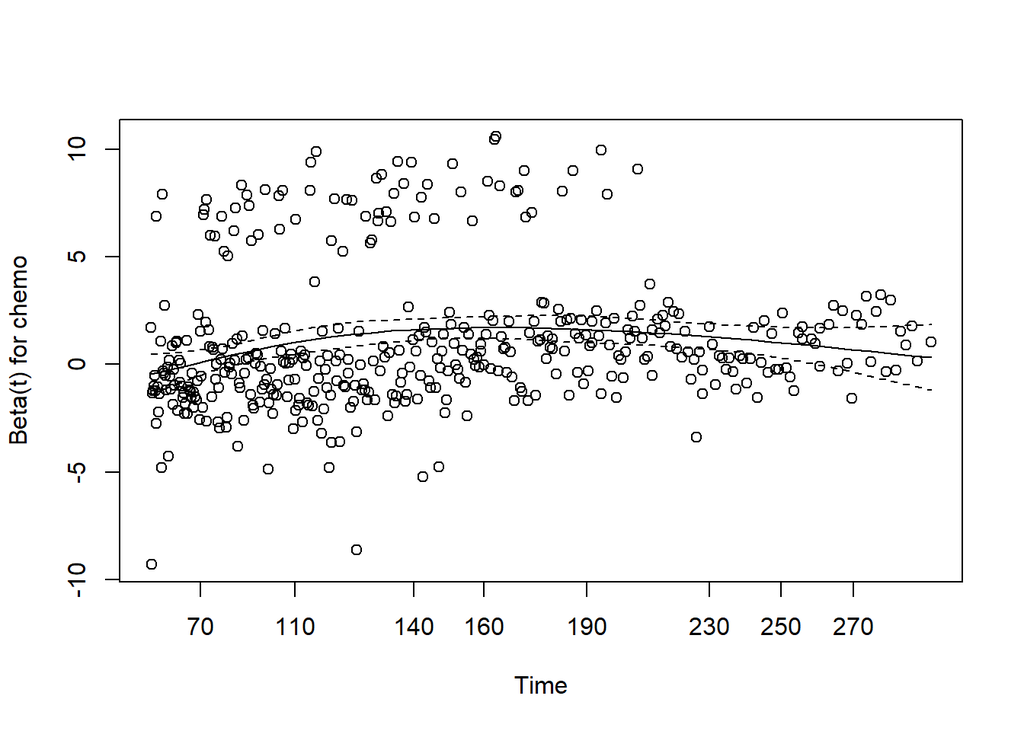

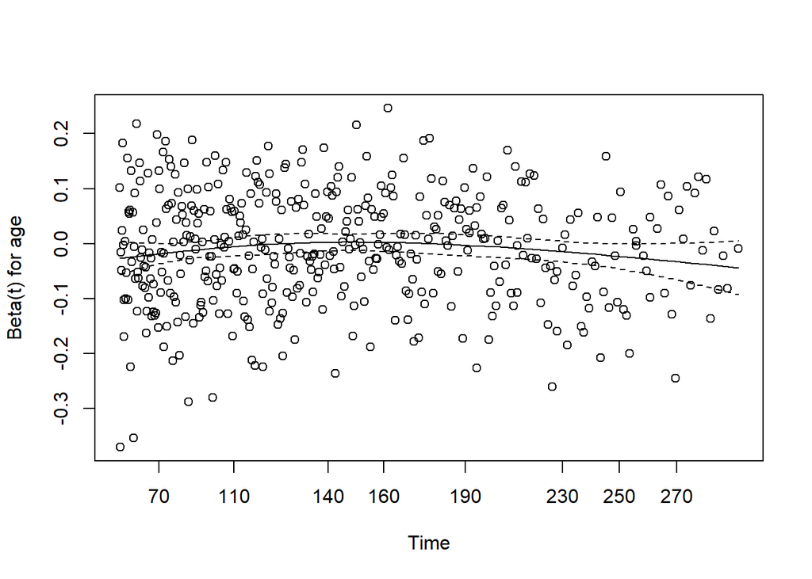

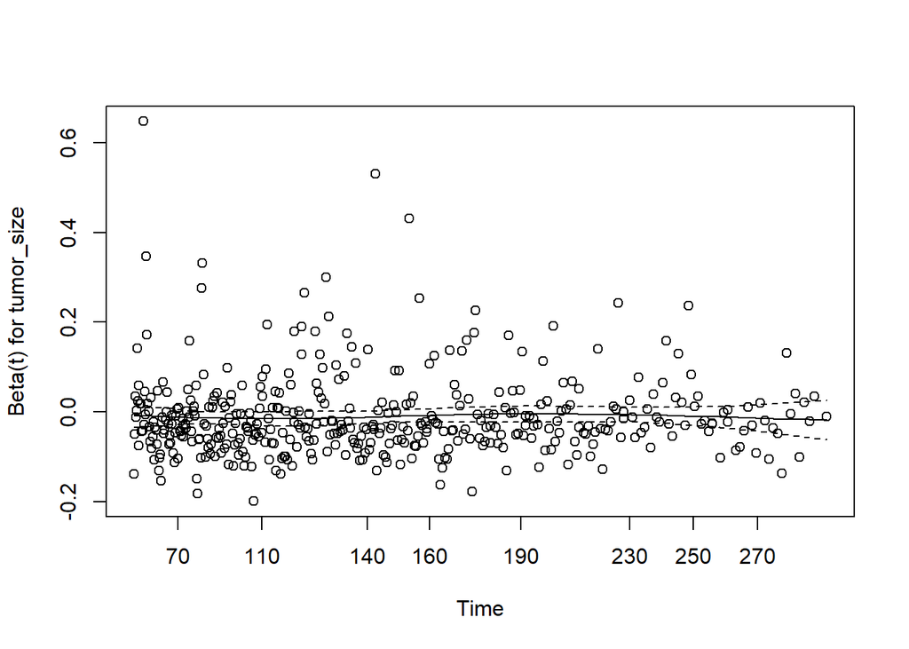

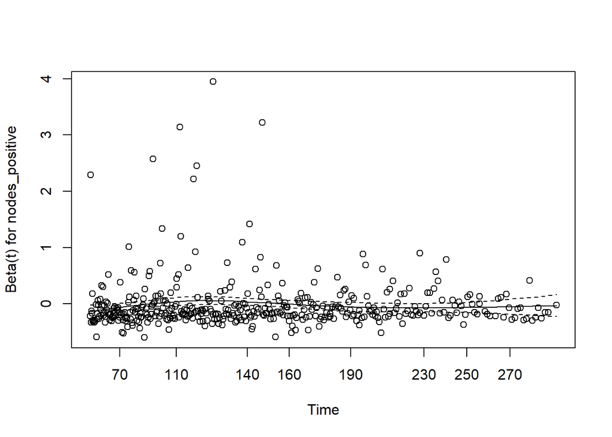

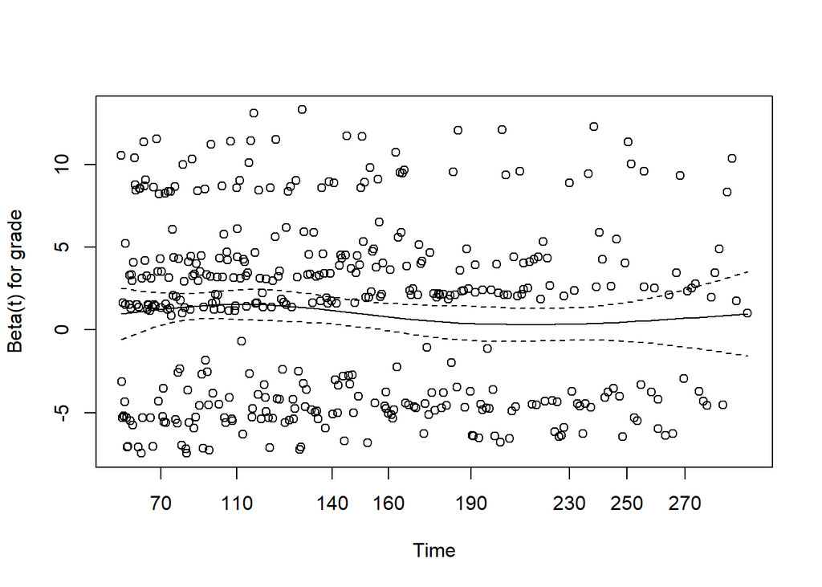

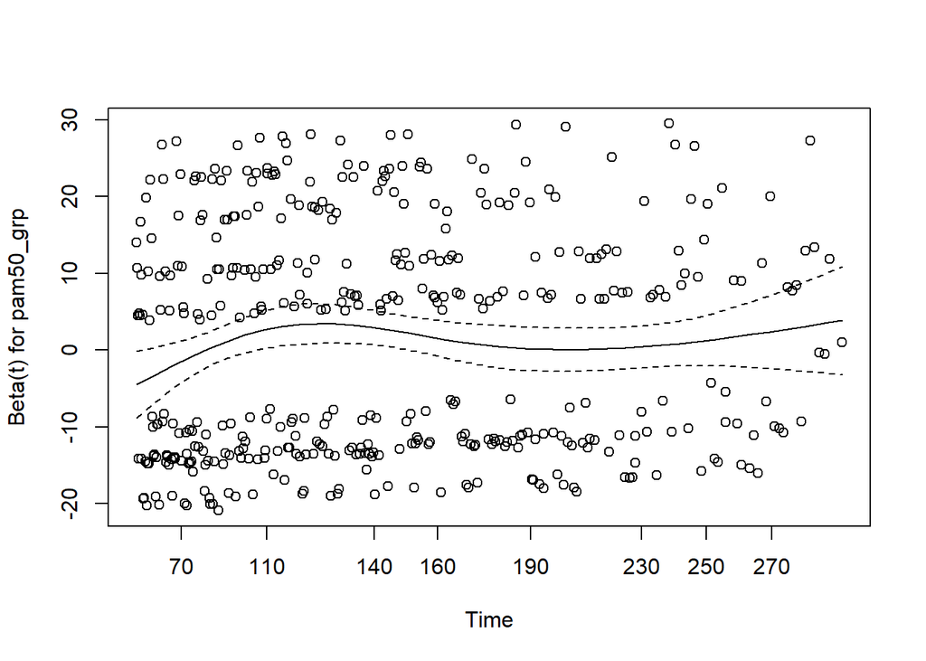

```r
plot(ccox_ph_res)
```

```r
# set up time-dependent crude cox
ccox_event_times <- sort(unique(dat_ccox$os_months[dat_ccox$os_event == 1]))
ccox_event_times <- ccox_event_times[-1]

dat_ccox_split <- survSplit(
  data = dat_ccox,
  cut = ccox_event_times,
  end = "os_months",
  start = "t0",
  event = "os_event"
) %>%
  mutate(
    chemo_t = chemo_num * log(os_months)
  )
```

```r
# fit time-dependent crude cox
ccox_td_fit <- coxph(
  Surv(t0, os_months, os_event) ~
    chemo_num +
    chemo_t +
    age +
    tumor_size +
    nodes_positive +
    grade +
    pam50_grp,
  data = dat_ccox_split,
  ties = "breslow"
)

summary(ccox_td_fit)
```

```
Call:
coxph(formula = Surv(t0, os_months, os_event) ~ chemo_num + chemo_t +
    age + tumor_size + nodes_positive + grade + pam50_grp, data = dat_ccox_split,
    ties = "breslow")

  n= 162869, number of events= 422

                    coef exp(coef)  se(coef)      z Pr(>|z|)
chemo_num      -5.278186  0.005102  1.839592 -2.869 0.004115 **
chemo_t         1.358739  3.891285  0.386986  3.511 0.000446 ***
age            -0.009653  0.990393  0.005081 -1.900 0.057445 .
tumor_size     -0.010012  0.990038  0.004505 -2.222 0.026269 *
nodes_positive -0.020494  0.979714  0.020253 -1.012 0.311574
grade2         -0.257568  0.772929  0.148677 -1.732 0.083203 .
grade3         -0.566757  0.567362  0.157587 -3.596 0.000323 ***
pam50_grpLumB   0.120495  1.128055  0.119791  1.006 0.314475
pam50_grpOther  0.164354  1.178632  0.128846  1.276 0.202101
---
Signif. codes:  0 '***' 0.001 '**' 0.01 '*' 0.05 '.' 0.1 ' ' 1

               exp(coef) exp(-coef) lower .95 upper .95
chemo_num       0.005102   196.0139 0.0001386    0.1877
chemo_t         3.891285     0.2570 1.8225959    8.3080
age             0.990393     1.0097 0.9805792    1.0003
tumor_size      0.990038     1.0101 0.9813347    0.9988
nodes_positive  0.979714     1.0207 0.9415871    1.0194
grade2          0.772929     1.2938 0.5775441    1.0344
grade3          0.567362     1.7625 0.4166028    0.7727
pam50_grpLumB   1.128055     0.8865 0.8919984    1.4266
pam50_grpOther  1.178632     0.8484 0.9155971    1.5172

Concordance= 0.613  (se = 0.017 )
Likelihood ratio test= 88.07  on 9 df,   p=4e-15
Wald test            = 103.2  on 9 df,   p=<2e-16
Score (logrank) test = 106.2  on 9 df,   p=<2e-16
```

```r
# check ph for td crude cox
ccox_td_ph_res <- cox.zph(ccox_td_fit)
ccox_td_ph_res
```

```
               chisq df     p
chemo_num      4.301  1 0.038
chemo_t        4.185  1 0.041
age            0.209  1 0.647
tumor_size     0.131  1 0.718
nodes_positive 0.170  1 0.680
grade          3.146  2 0.207
pam50_grp      3.050  2 0.218
GLOBAL         9.896  9 0.359
```

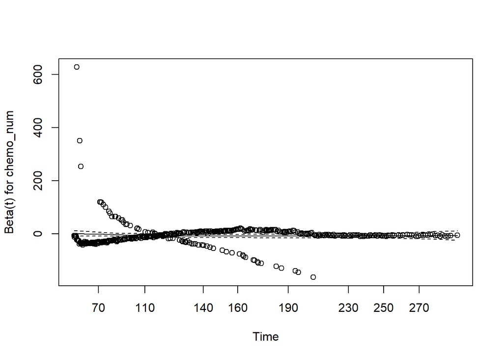

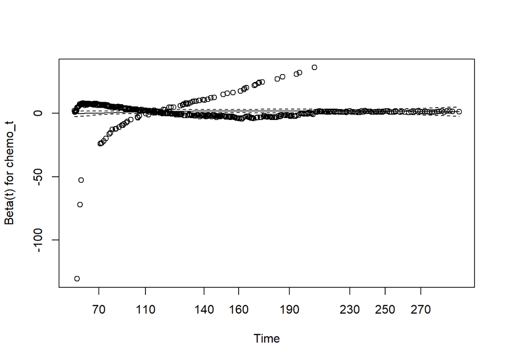

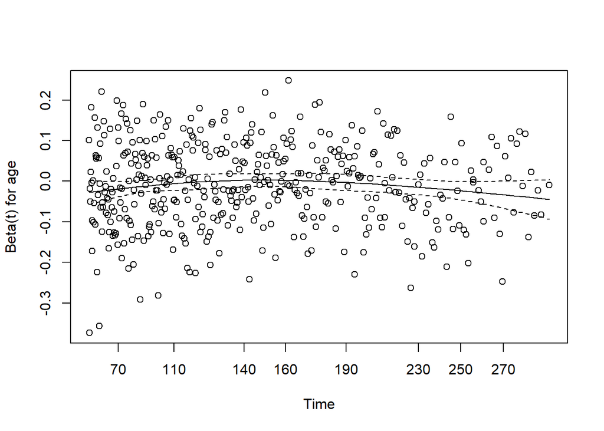

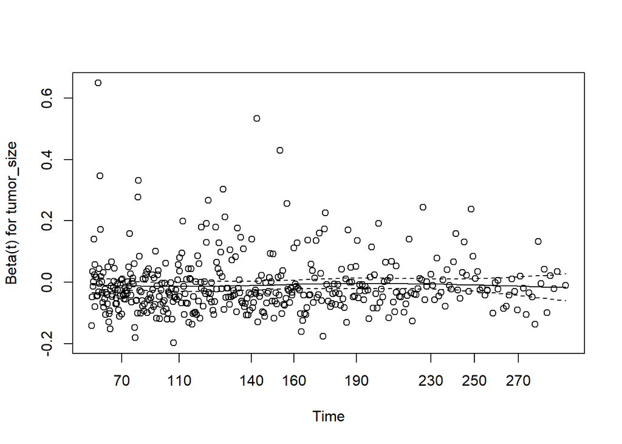

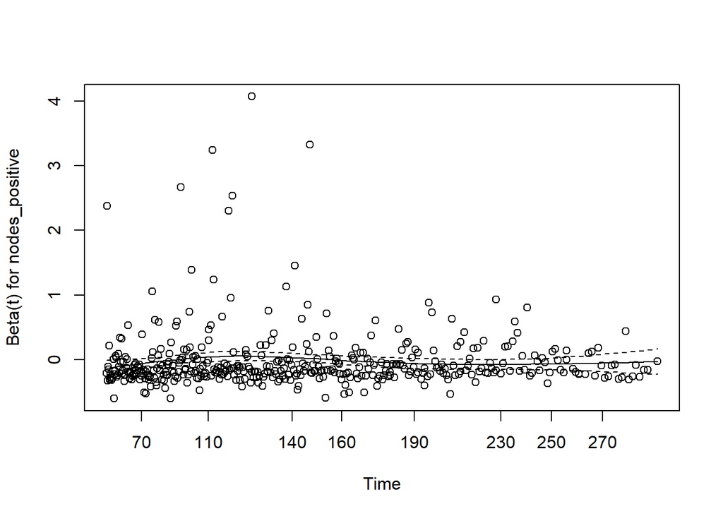

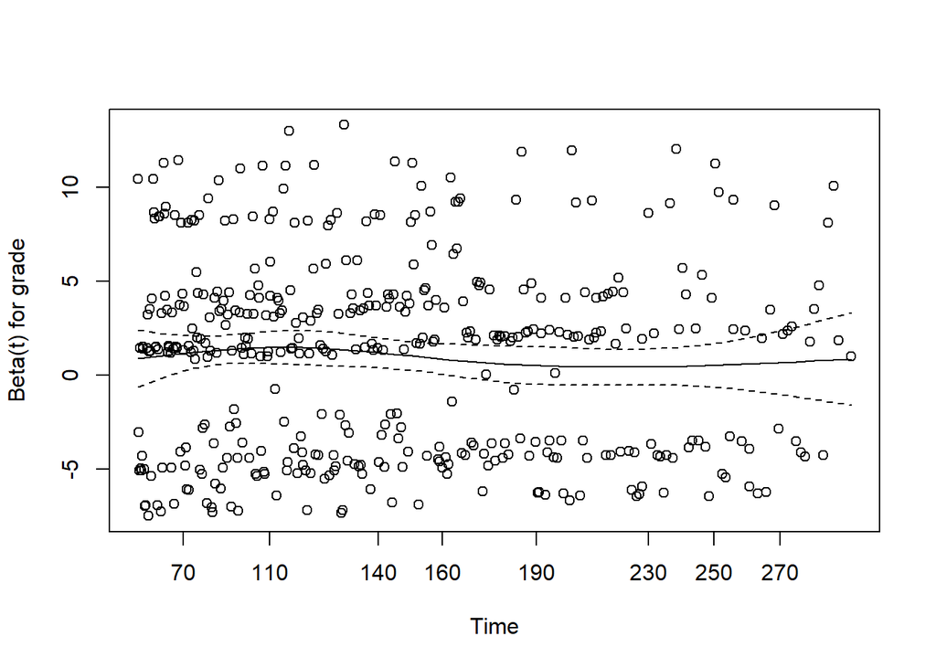

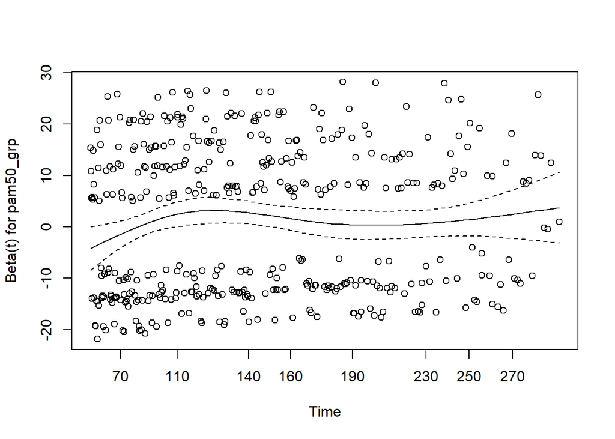

```r
plot(ccox_td_ph_res)
```

## 5 Gene variable selection: LASSO/SCAD/MCP/coxBAR

The following penalized regression methods were applied for gene selection:

• LASSO (Least Absolute Shrinkage and Selection Operator) • BAR (Broken Adaptive Ridge) • SCAD (Smoothly Clipped Absolute Deviation) • MCP (Minimax Concave Penalty)

```r
library(ncvreg)
```

### 5.1 set up data for penalized regression

The analysis was restricted to ER-positive patients who received hormone therapy, consistent with the main study cohort.

We would also restrict the sample to ER+ and hormone_therapy ==1 only, same as our analysis cohort.

```r
dat_gene0 <- dat0 %>%
  select(
    patient_id,
    er_status,
    hormone_therapy,
    chemotherapy,
    os_months = overall_survival_months,
    os_event = overall_survival,
    brca1:siah1_mut
  )

dat_gene1 <- dat_gene0 %>%
  mutate(
    across(where(is.character), ~na_if(.x, "")),
    across(c(er_status, hormone_therapy, chemotherapy), as.character),
    across(c(os_months, os_event), as.numeric),
    across(brca1:ugt2b7, as.numeric),
    across(
      pik3ca_mut:siah1_mut,
      ~case_when(
        is.na(.x) ~ NA_real_,
        .x == "0" ~ 0,
        TRUE ~ 1
      )
    )
  )

dat_lasso0 <- dat_gene1 %>%
  filter(
    er_status == "Positive",
    hormone_therapy == 1
  ) %>%
  filter(
    !is.na(chemotherapy),
    !is.na(os_months),
    !is.na(os_event)
  )
```

```r
gene_df <- dat_lasso0 %>%
  select(brca1:siah1_mut)

col_na <- colSums(is.na(gene_df))

col_var0 <- sapply(gene_df, function(x) var(x, na.rm = TRUE))
table(col_var0 == 0)
```

```
FALSE  TRUE
  660     2
```

```r
keep_gene <- names(gene_df)[col_na == 0 & col_var0 > 0]

dat_lasso <- dat_lasso0 %>%
  select(patient_id, er_status, hormone_therapy, chemotherapy, os_months, os_event,
         all_of(keep_gene))
```

```r
X <- dat_lasso %>%
  select(all_of(keep_gene)) %>%
  as.data.frame() %>%
  as.matrix()

sum(is.na(X)) # should be 0
```

```
[1] 0
```

```r
dim(X) # should be 662-2 = 660
```

```
[1] 1047  660
```

```r
X <- scale(X)
```

### 5.2 LASSO

```r
library(ncvreg)

set.seed(215)

fit <- cv.ncvsurv(
  X,
  Surv(dat_lasso$os_months, dat_lasso$os_event),
  penalty = "lasso",
  nlambda = 50,
  nfolds = 10
)
```

```r
fit.lasso <- ncvsurv(
  X,
  Surv(dat_lasso$os_months, dat_lasso$os_event),
  penalty = "lasso",
  lambda = fit$lambda.min
)
fit$lambda.min
```

```
[1] 0.03630447
```

```r
range(fit$lambda)
```

```
[1] 0.001231891 0.171170744
```

```r
which.min(abs(fit$lambda - fit$lambda.min))
```

```
[1] 12
```

```r
length(fit$lambda)
```

```
[1] 36
```

selected variables:

```r
lasso_coef <- coef(fit.lasso)

lasso_selected <- names(lasso_coef)[lasso_coef != 0]

lasso_selected
```

```
 [1] "rb1"         "ccnb1"       "myc"         "e2f5"        "jak1"
 [6] "jak2"        "adam17"      "psen1"       "apaf1"       "atr"
[11] "casp10"      "casp8"       "cxcr1"       "foxo1"       "inhba"
[16] "kit"         "mapk14"      "pdpk1"       "smad2"       "smad4"
[21] "terc"        "tsc1"        "tsc2"        "kmt2c"       "bbc3"
[26] "bmf"         "aff2"        "nek1"        "sbno1"       "sf3b1"
[31] "sik1"        "bche"        "hsd17b11"    "hsd17b4"     "hsd3b7"
[36] "star"        "ugt2b7"      "tg_mut"      "col12a1_mut" "arid1b_mut"
[41] "ptprd_mut"   "nek1_mut"    "cdkn2a_mut"  "klrg1_mut"
```

```r
lasso_selected_df <- data.frame(
  variable = names(lasso_coef)[lasso_coef != 0],
  coef = lasso_coef[lasso_coef != 0]
) %>%
  arrange(desc(abs(coef)))

lasso_selected_df
```

```
               variable         coef
tsc2               tsc2 -0.160383934
bbc3               bbc3  0.122127443
casp8             casp8  0.120465606
pdpk1             pdpk1  0.120183933
tsc1               tsc1 -0.081480192
smad2             smad2  0.068838946
adam17           adam17  0.046509084
sbno1             sbno1 -0.045108351
mapk14           mapk14  0.044779669
ccnb1             ccnb1 -0.044410916
hsd17b4         hsd17b4 -0.043868406
nek1_mut       nek1_mut -0.043646834
hsd17b11       hsd17b11  0.040386163
foxo1             foxo1  0.040082073
cxcr1             cxcr1  0.039624596
bche               bche -0.038140797
casp10           casp10  0.037562989
arid1b_mut   arid1b_mut -0.036922981
apaf1             apaf1 -0.035949315
sik1               sik1  0.034253141
ptprd_mut     ptprd_mut -0.027831128
kit                 kit  0.025989665
inhba             inhba  0.024402032
smad4             smad4  0.024269832
e2f5               e2f5  0.024020784
kmt2c             kmt2c -0.023664943
myc                 myc  0.023528762
jak1               jak1  0.021589629
psen1             psen1  0.021362971
sf3b1             sf3b1  0.020765132
jak2               jak2  0.020737411
cdkn2a_mut   cdkn2a_mut -0.016545360
rb1                 rb1  0.015082791
klrg1_mut     klrg1_mut -0.014669111
ugt2b7           ugt2b7  0.012006412
nek1               nek1 -0.011626296
bmf                 bmf -0.009279890
aff2               aff2  0.008689420
atr                 atr  0.006477945
col12a1_mut col12a1_mut -0.006052548
terc               terc  0.004353591
star               star  0.004102188
tg_mut           tg_mut -0.001932730
hsd3b7           hsd3b7 -0.001562209
```

### 5.3 SCAD

```r
set.seed(215)

fit <- cv.ncvsurv(
  X,
  Surv(dat_lasso$os_months, dat_lasso$os_event),
  penalty = "SCAD",
  nlambda = 50,
  nfolds = 10
)
# check ups (avoid the case if only a few fits worked)
fit$lambda.min
```

```
[1] 0.03153085
```

```r
range(fit$lambda)
```

```
[1] 0.0237841 0.1711707
```

```r
which.min(abs(fit$lambda - fit$lambda.min))
```

```
[1] 13
```

```r
length(fit$lambda)
```

```
[1] 15
```

```r
fit.scad <- ncvsurv(
  X,
  Surv(dat_lasso$os_months, dat_lasso$os_event),
  penalty = "SCAD",
  lambda = fit$lambda.min
)
```

```r
scad_coef <- coef(fit.scad)

scad_selected <- names(scad_coef)[scad_coef != 0]

scad_selected
```

```
 [1] "e2f5"        "jak1"        "adam17"      "apaf1"       "casp10"
 [6] "casp8"       "cxcr1"       "fgfr1"       "foxo1"       "inhba"
[11] "mapk14"      "mmp13"       "mmp21"       "pdpk1"       "smad2"
[16] "tsc1"        "tsc2"        "kmt2c"       "bbc3"        "bmf"
[21] "afdn"        "aff2"        "ahnak2"      "foxp1"       "ldlrap1"
[26] "muc16"       "nek1"        "sbno1"       "sik1"        "stab2"
[31] "taf4b"       "thsd7a"      "bche"        "hsd17b4"     "prkd1"
[36] "star"        "ugt2b7"      "gata3_mut"   "kmt2d_mut"   "ush2a_mut"
[41] "tg_mut"      "col12a1_mut" "arid1b_mut"  "ptprd_mut"   "setd2_mut"
[46] "thsd7a_mut"  "myo3a_mut"   "nek1_mut"    "cdkn2a_mut"  "tbl1xr1_mut"
[51] "klrg1_mut"
```

```r
scad_selected_df <- data.frame(
  variable = names(scad_coef)[scad_coef != 0],
  coef = scad_coef[scad_coef != 0]
) %>%
  arrange(desc(abs(coef)))

scad_selected_df
```

```
               variable          coef
tsc2               tsc2 -0.4597339016
pdpk1             pdpk1  0.4320182117
foxo1             foxo1  0.2744399791
bbc3               bbc3  0.2091348068
nek1_mut       nek1_mut -0.1014059590
smad2             smad2  0.0695114711
ptprd_mut     ptprd_mut -0.0645552190
sbno1             sbno1 -0.0588587329
aff2               aff2  0.0545935307
tsc1               tsc1 -0.0509877058
bche               bche -0.0460856942
nek1               nek1 -0.0449513917
hsd17b4         hsd17b4 -0.0432285980
bmf                 bmf -0.0404918176
e2f5               e2f5  0.0336593015
casp10           casp10  0.0331846118
cxcr1             cxcr1  0.0314977400
mmp13             mmp13 -0.0287791229
cdkn2a_mut   cdkn2a_mut -0.0279160667
ugt2b7           ugt2b7  0.0272282188
ldlrap1         ldlrap1  0.0250056090
apaf1             apaf1 -0.0249454301
kmt2c             kmt2c -0.0246601690
adam17           adam17  0.0242827945
sik1               sik1  0.0238539612
mmp21             mmp21  0.0237933674
casp8             casp8  0.0236510025
klrg1_mut     klrg1_mut -0.0196638575
star               star  0.0192373236
fgfr1             fgfr1 -0.0171655314
ush2a_mut     ush2a_mut -0.0166086231
inhba             inhba  0.0165874686
tbl1xr1_mut tbl1xr1_mut  0.0165480001
mapk14           mapk14  0.0159333617
thsd7a           thsd7a  0.0146839579
muc16             muc16 -0.0135091209
myo3a_mut     myo3a_mut -0.0131374265
arid1b_mut   arid1b_mut -0.0128824528
afdn               afdn -0.0107374662
foxp1             foxp1  0.0095787826
col12a1_mut col12a1_mut -0.0094793361
jak1               jak1  0.0091100762
ahnak2           ahnak2 -0.0079213582
tg_mut           tg_mut -0.0068209732
prkd1             prkd1 -0.0049338636
setd2_mut     setd2_mut -0.0048284534
gata3_mut     gata3_mut  0.0039944521
thsd7a_mut   thsd7a_mut -0.0035279499
stab2             stab2 -0.0019538508
kmt2d_mut     kmt2d_mut -0.0012604044
taf4b             taf4b  0.0005334334
```

### 5.4 MCP

```r
set.seed(215)

fit <- cv.ncvsurv(
  X,
  Surv(dat_lasso$os_months, dat_lasso$os_event),
  penalty = "MCP",
  nlambda = 50,
  nfolds = 10
)
fit$lambda.min
```

```
[1] 0.04812925
```

```r
range(fit$lambda)
```

```
[1] 0.03153085 0.17117074
```

```r
which.min(abs(fit$lambda - fit$lambda.min))
```

```
[1] 10
```

```r
length(fit$lambda)
```

```
[1] 13
```

```r
fit.mcp <- ncvsurv(
  X,
  Surv(dat_lasso$os_months, dat_lasso$os_event),
  penalty = "MCP",
  lambda = fit$lambda.min
)
```

```r
mcp_coef <- coef(fit.mcp)

mcp_selected <- names(mcp_coef)[mcp_coef != 0]

mcp_selected
```

```
 [1] "apaf1"      "casp10"     "foxo1"      "pdpk1"      "smad2"
 [6] "tsc1"       "tsc2"       "bbc3"       "aff2"       "nek1"
[11] "sbno1"      "thsd7a"     "ptprd_mut"  "nek1_mut"   "cdkn2a_mut"
[16] "klrg1_mut"
```

```r
mcp_selected_df <- data.frame(
  variable = names(mcp_coef)[mcp_coef != 0],
  coef = mcp_coef[mcp_coef != 0]
) %>%
  arrange(desc(abs(coef)))

mcp_selected_df
```

```
             variable         coef
tsc2             tsc2 -0.492010769
pdpk1           pdpk1  0.441733744
foxo1           foxo1  0.236250081
bbc3             bbc3  0.174826217
nek1_mut     nek1_mut -0.079719712
nek1             nek1 -0.066460133
smad2           smad2  0.061100617
ptprd_mut   ptprd_mut -0.056716786
sbno1           sbno1 -0.050474602
thsd7a         thsd7a  0.039185253
tsc1             tsc1 -0.036403880
casp10         casp10  0.020011922
klrg1_mut   klrg1_mut -0.011462369
cdkn2a_mut cdkn2a_mut -0.009237028
aff2             aff2  0.006374857
apaf1           apaf1 -0.001852963
```

### 5.5 coxBAR

```r
library(Cyclops)
library(BrokenAdaptiveRidge)
```

```r
library(Cyclops)
library(BrokenAdaptiveRidge)
library(survival)

set.seed(215)

ncov <- ncol(X)
n <- nrow(X)

dataFit <- createCyclopsData(
  Surv(dat_lasso$os_months, dat_lasso$os_event) ~ X,
  modelType = "cox"
)

pen_grid <- exp(seq(log(0.1 * log(ncov)), log(1 * log(ncov)), length.out = 50))

coxbar_grid <- lapply(pen_grid, function(pen) {

  barPrior <- createBarPrior(
    penalty = pen,
    initialRidgeVariance = 1 / pen
  )

  fit.bar <- try(
    fitCyclopsModel(dataFit, prior = barPrior),
    silent = TRUE
  )

  if(inherits(fit.bar, "try-error")) {
    return(list(
      penalty = pen,
      fit = NULL,
      bic = Inf,
      refit_warn = FALSE,
      refit_ok = FALSE
    ))
  }

  coef_bar <- try(coef(fit.bar), silent = TRUE)

  if(inherits(coef_bar, "try-error") || is.null(coef_bar)) {
    return(list(
      penalty = pen,
      fit = NULL,
      bic = Inf,
      refit_warn = FALSE,
      refit_ok = FALSE
    ))
  }

  selected_idx <- which(coef_bar != 0)
  k <- length(selected_idx)

  if(k == 0) {
    fit_null <- coxph(Surv(os_months, os_event) ~ 1, data = dat_lasso)

    bic <- -2 * as.numeric(logLik(fit_null)) + log(n) * k

    return(list(
      penalty = pen,
      fit = fit.bar,
      bic = bic,
      refit_warn = FALSE,
      refit_ok = TRUE
    ))
  } else {

    dat_bar <- data.frame(
      os_months = dat_lasso$os_months,
      os_event = dat_lasso$os_event,
      X[, selected_idx, drop = FALSE]
    )

    colnames(dat_bar)[3:ncol(dat_bar)] <- colnames(X)[selected_idx]

    warn_msg <- NULL

    fit_refit <- tryCatch(
      withCallingHandlers(
        coxph(
          as.formula(
            paste(
              "Surv(os_months, os_event) ~",
              paste(colnames(X)[selected_idx], collapse = " + ")
            )
          ),
          data = dat_bar
        ),
        warning = function(w) {
          warn_msg <<- conditionMessage(w)
          invokeRestart("muffleWarning")
        }
      ),
      error = function(e) NULL
    )

    if(is.null(fit_refit)) {
      bic <- Inf
      refit_ok <- FALSE
    } else {
      bic <- -2 * as.numeric(logLik(fit_refit)) + log(n) * k
      refit_ok <- TRUE
    }

    return(list(
      penalty = pen,
      fit = fit.bar,
      bic = bic,
      refit_warn = !is.null(warn_msg),
      warn_msg = warn_msg,
      refit_ok = refit_ok
    ))
  }
})
```

```r
bic_values <- sapply(coxbar_grid, function(x) x$bic)

best_index <- which.min(bic_values)

pen_grid[best_index]
```

```
[1] 1.313763
```

```r
range(pen_grid)
```

```
[1] 0.649224 6.492240
```

```r
best_index
```

```
[1] 16
```

```r
length(pen_grid)
```

```
[1] 50
```

best fit model:

```r
fit.coxbar <- coxbar_grid[[best_index]]$fit

coef_bar <- coef(fit.coxbar)
```

selected variables:

```r
coxbar_selected <- colnames(X)[coef_bar != 0]

coxbar_selected
```

```
 [1] "cdkn2b"    "casp8"     "mapk14"    "pdgfa"     "smad4"     "tsc2"
 [7] "kmt2c"     "bbc3"      "ahnak"     "ldlrap1"   "sbno1"     "setd1a"
[13] "taf1"      "hsd17b14"  "hsd17b4"   "kmt2d_mut" "ptprd_mut" "nek1_mut"
```

```r
coxbar_selected_df <- data.frame(
  variable = colnames(X)[coef_bar != 0],
  coef = coef_bar[coef_bar != 0]
) %>%
  arrange(desc(abs(coef)))

coxbar_selected_df
```

```
            variable        coef
Xtsc2           tsc2 -0.33246317
Xkmt2c         kmt2c -0.27860009
Xmapk14       mapk14  0.27524096
Xcasp8         casp8  0.26146084
Xbbc3           bbc3  0.24675829
Xsbno1         sbno1 -0.20964952
Xsetd1a       setd1a  0.18213530
Xldlrap1     ldlrap1  0.17583519
Xtaf1           taf1  0.16373477
Xhsd17b4     hsd17b4 -0.14872233
Xsmad4         smad4  0.14261635
Xptprd_mut ptprd_mut -0.13929264
Xahnak         ahnak -0.13864922
Xnek1_mut   nek1_mut -0.12934644
Xcdkn2b       cdkn2b  0.12014934
Xhsd17b14   hsd17b14 -0.11005163
Xpdgfa         pdgfa  0.10043988
Xkmt2d_mut kmt2d_mut -0.08189969
```

```r
sum(is.infinite(bic_values))
```

```
[1] 2
```

```r
sum(sapply(coxbar_grid, function(x) x$refit_warn), na.rm = TRUE)
```

```
[1] 1
```

```r
sum(sapply(coxbar_grid, function(x) x$refit_ok), na.rm = TRUE)
```

```
[1] 48
```

Only 2 of the 50 penalty values failed during fitting. Only 1 run produced an infinite-coefficient warning in the refitted Cox model. Overall, 48 penalty values produced stable refitted Cox models.

### 5.6 compare methods

```r
gene_sets <- list(
  lasso = lasso_selected,
  scad = scad_selected,
  mcp = mcp_selected,
  coxbar = coxbar_selected
)
```

```r
refit_compare <- lapply(names(gene_sets), function(m) {

  vars <- gene_sets[[m]]

  dat_tmp <- dat_lasso %>%
    select(os_months, os_event, all_of(vars))

  fit_tmp <- coxph(
    as.formula(
      paste("Surv(os_months, os_event) ~", paste(vars, collapse = " + "))
    ),
    data = dat_tmp
  )

  data.frame(
    method = m,
    n_var = length(vars),
    logLik = as.numeric(logLik(fit_tmp)),
    AIC = AIC(fit_tmp),
    BIC = BIC(fit_tmp)
  )
}) %>%
  bind_rows() %>%
  arrange(BIC)

refit_compare
```

```
  method n_var    logLik      AIC      BIC
1 coxbar    18 -2303.086 4642.172 4715.362
2    mcp    16 -2312.698 4657.397 4722.454
3   scad    51 -2245.468 4592.936 4800.308
4  lasso    44 -2272.039 4632.078 4810.986
```

### 5.7 select variables

Our aim was to select 5 to 8 final gene variables for inclusion in the Cox model.

why choose CoxBAR as the main model: In addition that coxBAR gives best BIC, the main reason is because our goal was sparse and stable variable screening in a correlated genomic setting, we treated CoxBAR as the primary penalized Cox selection method. CoxBAR is a surrogate ℓ0 penalized Cox approach based on broken adaptive ridge and has been shown to have selection consistency, oracle property for parameter estimation, and a grouping property for highly correlated covariates. In simulation and empirical evaluations, BAR-based Cox regression selected relatively sparse models and achieved model selection and discriminatory performance comparable to or slightly better than Cox LASSO, with less biased and more stable solution paths under BIC-based tuning.

summarize overlap among selected variables:

```r
all_selected <- list(
  lasso = lasso_selected,
  scad = scad_selected,
  mcp = mcp_selected,
  coxbar = coxbar_selected
)

all_genes <- sort(unique(unlist(all_selected)))

overlap_df <- data.frame(variable = all_genes) %>%
  mutate(
    in_lasso = variable %in% lasso_selected,
    in_scad = variable %in% scad_selected,
    in_mcp = variable %in% mcp_selected,
    in_coxbar = variable %in% coxbar_selected,
    n_methods = in_lasso + in_scad + in_mcp + in_coxbar
  ) %>%
  arrange(desc(n_methods), variable)

overlap_df
```

```
      variable in_lasso in_scad in_mcp in_coxbar n_methods
1         bbc3     TRUE    TRUE   TRUE      TRUE         4
2     nek1_mut     TRUE    TRUE   TRUE      TRUE         4
3    ptprd_mut     TRUE    TRUE   TRUE      TRUE         4
4        sbno1     TRUE    TRUE   TRUE      TRUE         4
5         tsc2     TRUE    TRUE   TRUE      TRUE         4
6         aff2     TRUE    TRUE   TRUE     FALSE         3
7        apaf1     TRUE    TRUE   TRUE     FALSE         3
8       casp10     TRUE    TRUE   TRUE     FALSE         3
9        casp8     TRUE    TRUE  FALSE      TRUE         3
10  cdkn2a_mut     TRUE    TRUE   TRUE     FALSE         3
11       foxo1     TRUE    TRUE   TRUE     FALSE         3
12     hsd17b4     TRUE    TRUE  FALSE      TRUE         3
13   klrg1_mut     TRUE    TRUE   TRUE     FALSE         3
14       kmt2c     TRUE    TRUE  FALSE      TRUE         3
```

[output cut: 55 more lines]

The variables selected by all 4 methods were tsc2, bbc3, sbno1, ptprd_mut, and nek1_mut.

Because ptprd_mut and nek1_mut were originally recorded as either 0 or mutation-type strings, they were recoded as binary mutation indicators, with 1 indicating mutation and 0 indicating no mutation, before being entered into the Cox model.

## 6 Crude Cox with selected genes

### 6.1 set up data

```r
hx_dat0 <- METABRIC_RNA_Mutation %>%
  as_tibble()

hx_dat1 <- hx_dat0 %>%
  transmute(
    patient_id,
    er_status,
    hormone_therapy,
    chemotherapy,
    os_months = overall_survival_months,
    os_event  = overall_survival,

    age = age_at_diagnosis,
    tumor_size,
    nodes_positive = lymph_nodes_examined_positive,
    grade = neoplasm_histologic_grade,
    her2 = her2_status,
    pam50 = `pam50_._claudin.low_subtype`,
    tumor_stage,
    menopausal_state = inferred_menopausal_state,
    pr_status,
    surgery = type_of_breast_surgery,
    radio_therapy,

    tsc2,
    bbc3,
    sbno1,
    ptprd_mut,
    nek1_mut,
    mapk14,
    kmt2c
  )

hx_dat2 <- hx_dat1 %>%
  mutate(
    across(where(is.character), ~ na_if(.x, "")),

    er_status       = as.character(er_status),
    hormone_therapy = as.character(hormone_therapy),
    chemotherapy    = as.character(chemotherapy),

    grade            = as.character(grade),
    her2             = as.character(her2),
    pam50            = as.character(pam50),
    tumor_stage      = as.character(tumor_stage),
    menopausal_state = as.character(menopausal_state),
    pr_status        = as.character(pr_status),
    surgery          = as.character(surgery),
    radio_therapy    = as.character(radio_therapy),

    os_months      = as.numeric(os_months),
    os_event       = as.numeric(os_event),
    age            = as.numeric(age),
    tumor_size     = as.numeric(tumor_size),
    nodes_positive = as.numeric(nodes_positive),

    tsc2   = as.numeric(tsc2),
    bbc3   = as.numeric(bbc3),
    sbno1  = as.numeric(sbno1),
    mapk14 = as.numeric(mapk14),
    kmt2c  = as.numeric(kmt2c)
  ) %>%
  mutate(
    hormone_therapy_num = case_when(
      hormone_therapy %in% c("1", 1) ~ 1,
      hormone_therapy %in% c("0", 0) ~ 0,
      TRUE ~ NA_real_
    ),
    chemotherapy_num = case_when(
      chemotherapy %in% c("1", 1) ~ 1,
      chemotherapy %in% c("0", 0) ~ 0,
      TRUE ~ NA_real_
    ),
    ptprd_mut_bin = case_when(
      is.na(ptprd_mut) ~ NA_real_,
      ptprd_mut %in% c("0", 0) ~ 0,
      TRUE ~ 1
    ),
    nek1_mut_bin = case_when(
      is.na(nek1_mut) ~ NA_real_,
      nek1_mut %in% c("0", 0) ~ 0,
      TRUE ~ 1
    )
  )

hx_dat_er <- hx_dat2 %>%
  filter(
    er_status == "Positive",
    hormone_therapy_num == 1
  )
```

```r
# set up data for crude cox and aft
hx_dat_model <- hx_dat_er %>%
  filter(
    !is.na(os_months),
    !is.na(os_event),
    !is.na(chemotherapy_num),
    !is.na(age),
    !is.na(tumor_size),
    !is.na(nodes_positive),
    !is.na(grade),
    !is.na(pam50),
    !is.na(tsc2),
    !is.na(bbc3),
    !is.na(sbno1),
    !is.na(ptprd_mut_bin),
    !is.na(nek1_mut_bin)
  ) %>%
  mutate(
    chemo = factor(
      chemotherapy_num,
      levels = c(0, 1),
      labels = c("Hormone only", "Hormone + Chemo")
    ),
    chemo_num = chemotherapy_num,
    grade = factor(grade),
    pam50_grp = case_when(
      pam50 %in% c("LumA", "LumB") ~ pam50,
      TRUE ~ "Other"
    )
  ) %>%
  mutate(
    pam50_grp = factor(pam50_grp, levels = c("LumA", "LumB", "Other")),
    ptprd_mut_bin = factor(ptprd_mut_bin, levels = c(0, 1), labels = c("No", "Yes")),
    nek1_mut_bin  = factor(nek1_mut_bin,  levels = c(0, 1), labels = c("No", "Yes"))
  ) %>%
  filter(!is.na(pam50_grp))

nrow(hx_dat_model)
```

```
[1] 1000
```

```r
table(hx_dat_model$chemo, useNA = "ifany")
```

```
   Hormone only Hormone + Chemo
            880             120
```

```r
table(hx_dat_model$grade, useNA = "ifany")
```

```
  1   2   3
101 458 441
```

```r
table(hx_dat_model$pam50_grp, useNA = "ifany")
```

```
 LumA  LumB Other
  440   355   205
```

### 6.2 Cox model without time-dependent chemotherapy

```r
# fit crude cox model
hx_cox_formula <- Surv(os_months, os_event) ~
  chemo +
  age +
  tumor_size +
  nodes_positive +
  grade +
  pam50_grp +
  tsc2 +
  bbc3 +
  sbno1 +
  ptprd_mut_bin +
  nek1_mut_bin

hx_cox_fit <- coxph(
  hx_cox_formula,
  data = hx_dat_model,
  ties = "breslow"
)

summary(hx_cox_fit)
```

```
Call:
coxph(formula = hx_cox_formula, data = hx_dat_model, ties = "breslow")

  n= 1000, number of events= 422

                          coef exp(coef)  se(coef)      z Pr(>|z|)
chemoHormone + Chemo  0.871195  2.389765  0.159736  5.454 4.93e-08 ***
age                  -0.004365  0.995644  0.005040 -0.866  0.38641
tumor_size           -0.006070  0.993948  0.004622 -1.313  0.18910
nodes_positive       -0.015179  0.984936  0.019425 -0.781  0.43456
grade2               -0.067654  0.934584  0.150925 -0.448  0.65396
grade3               -0.333260  0.716584  0.160837 -2.072  0.03826 *
pam50_grpLumB         0.013184  1.013271  0.129372  0.102  0.91883
pam50_grpOther        0.007818  1.007849  0.130306  0.060  0.95216
tsc2                 -0.359188  0.698243  0.056222 -6.389 1.67e-10 ***
bbc3                  0.239524  1.270644  0.052218  4.587 4.50e-06 ***
sbno1                -0.182353  0.833307  0.058663 -3.108  0.00188 **
ptprd_mut_binYes     -0.781777  0.457592  0.454406 -1.720  0.08535 .
nek1_mut_binYes      -0.984378  0.373672  0.509280 -1.933  0.05325 .
---
Signif. codes:  0 '***' 0.001 '**' 0.01 '*' 0.05 '.' 0.1 ' ' 1

                     exp(coef) exp(-coef) lower .95 upper .95
chemoHormone + Chemo    2.3898     0.4185    1.7474    3.2683
age                     0.9956     1.0044    0.9859    1.0055
tumor_size              0.9939     1.0061    0.9850    1.0030
nodes_positive          0.9849     1.0153    0.9481    1.0232
grade2                  0.9346     1.0700    0.6953    1.2563
grade3                  0.7166     1.3955    0.5228    0.9821
pam50_grpLumB           1.0133     0.9869    0.7863    1.3057
pam50_grpOther          1.0078     0.9922    0.7807    1.3011
tsc2                    0.6982     1.4322    0.6254    0.7796
bbc3                    1.2706     0.7870    1.1470    1.4076
sbno1                   0.8333     1.2000    0.7428    0.9348
ptprd_mut_binYes        0.4576     2.1854    0.1878    1.1150
nek1_mut_binYes         0.3737     2.6761    0.1377    1.0139

Concordance= 0.67  (se = 0.014 )
Likelihood ratio test= 140.8  on 13 df,   p=<2e-16
Wald test            = 142.5  on 13 df,   p=<2e-16
Score (logrank) test = 149.7  on 13 df,   p=<2e-16
```

```r
# vif check
hx_lm_proxy <- lm(
  os_months ~ chemo + age + tumor_size + nodes_positive + grade +
    pam50_grp + tsc2 + bbc3 + sbno1 + ptprd_mut_bin + nek1_mut_bin,
  data = hx_dat_model
)

vif(hx_lm_proxy)
```

```
                   GVIF Df GVIF^(1/(2*Df))
chemo          1.292326  1        1.136805
age            1.205964  1        1.098164
tumor_size     1.128818  1        1.062458
nodes_positive 1.125484  1        1.060888
grade          1.133934  2        1.031922
pam50_grp      1.235229  2        1.054234
tsc2           1.134780  1        1.065261
bbc3           1.031523  1        1.015639
sbno1          1.174052  1        1.083537
ptprd_mut_bin  1.010577  1        1.005274
nek1_mut_bin   1.016419  1        1.008176
```

```r
# ph assumption check
hx_ph_res <- cox.zph(hx_cox_fit)
hx_ph_res
```

```
                 chisq df       p
chemo          24.6473  1 6.9e-07
age             0.0931  1 0.76027
tumor_size      1.9145  1 0.16647
nodes_positive  1.3864  1 0.23902
grade           6.1902  2 0.04527
pam50_grp       2.6564  2 0.26496
tsc2            0.2480  1 0.61848
bbc3            0.0242  1 0.87637
sbno1           4.7979  1 0.02850
ptprd_mut_bin   0.5351  1 0.46448
nek1_mut_bin    0.4913  1 0.48335
GLOBAL         38.5017 13 0.00024
```

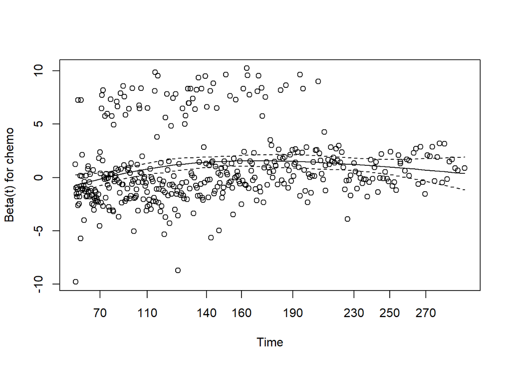

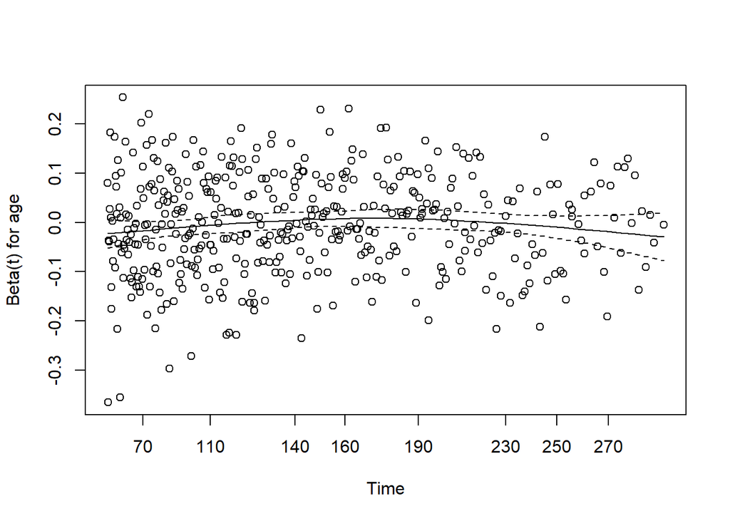

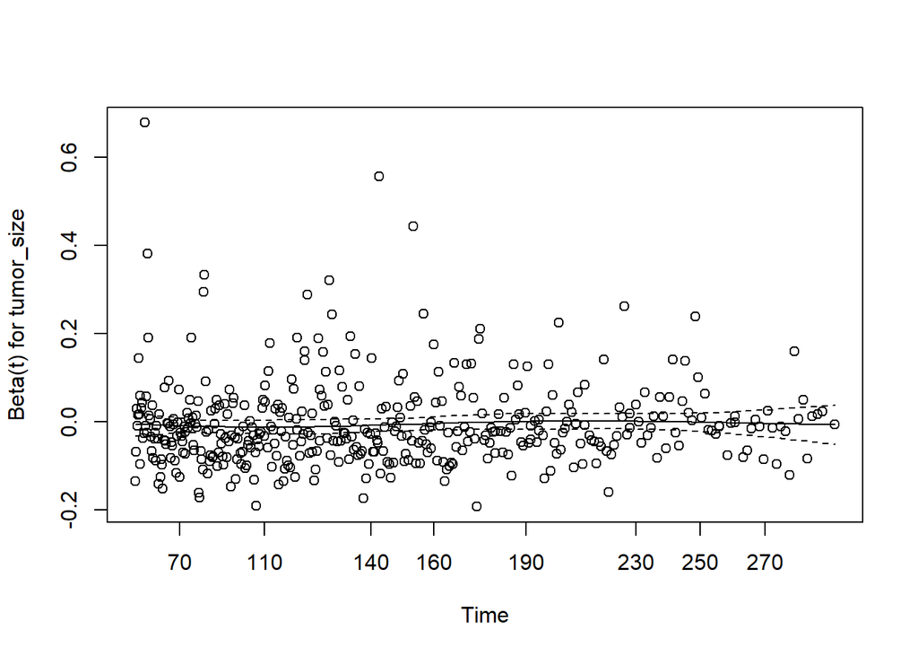

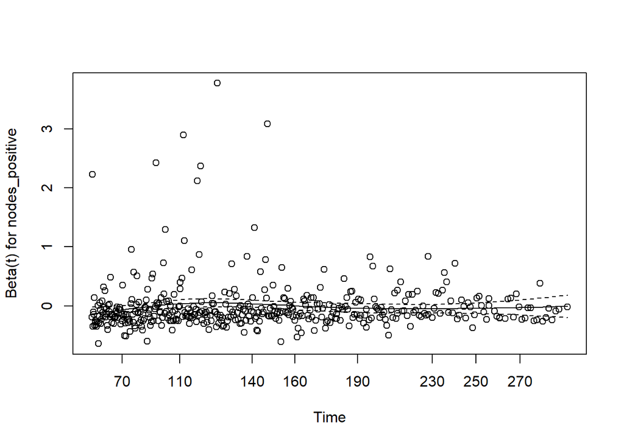

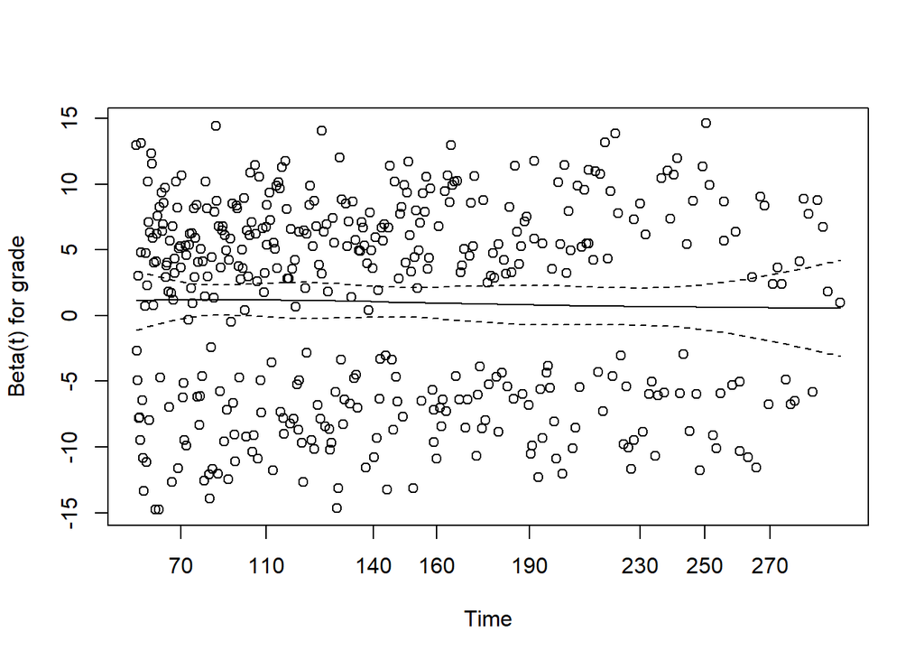

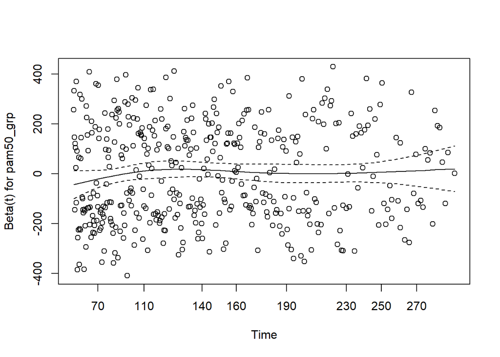

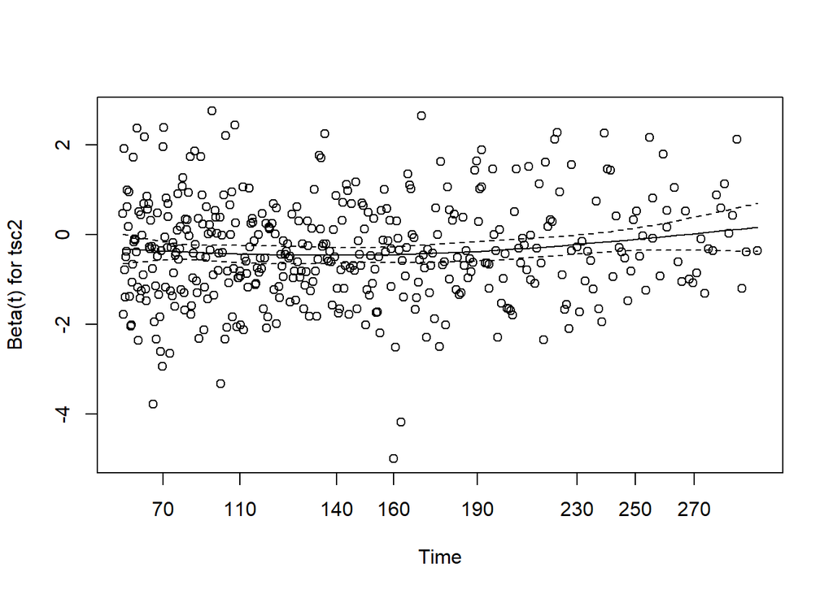

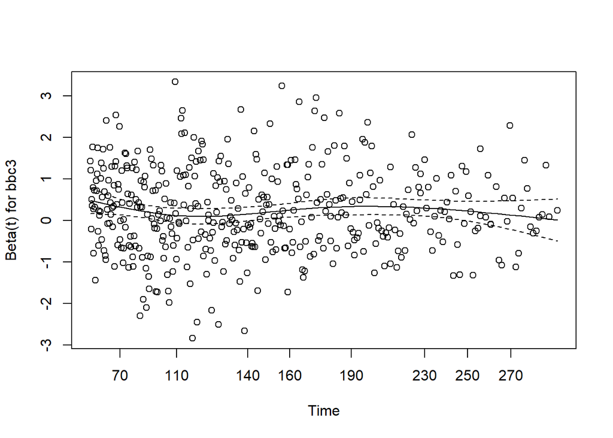

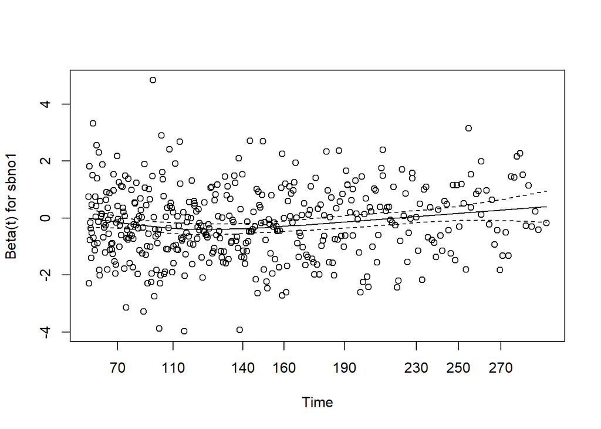

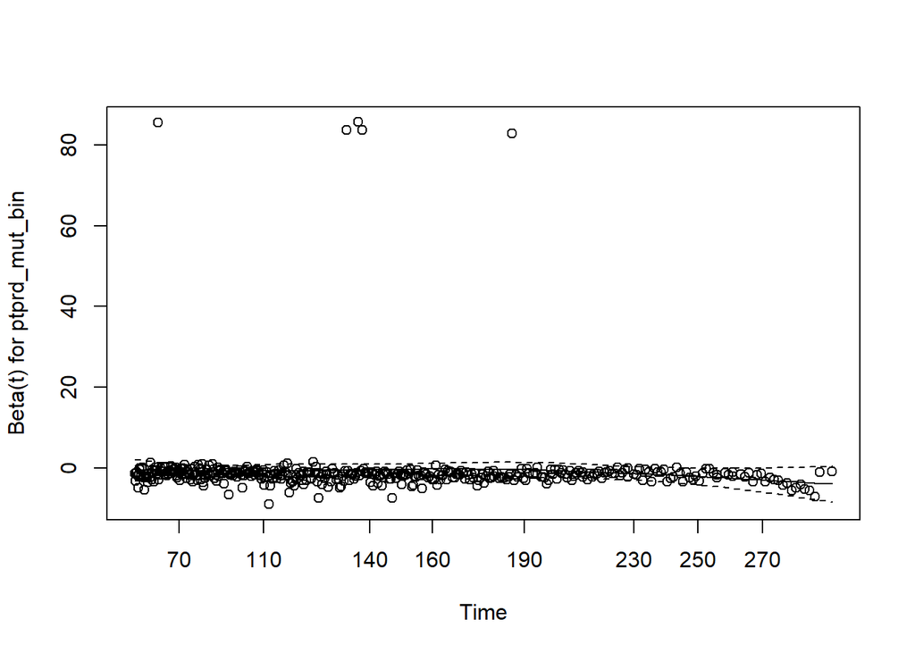

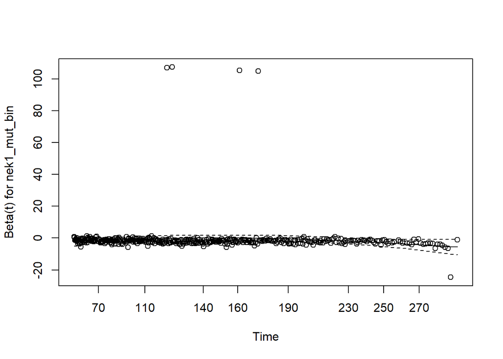

```r
plot(hx_ph_res)
```

### 6.3 Cox model with time-dependent chemotherapy

```r
# time-dependent cox
hx_event_times <- sort(unique(hx_dat_model$os_months[hx_dat_model$os_event == 1]))
hx_event_times <- hx_event_times[-1]

hx_dat_split <- survSplit(
  data  = hx_dat_model,
  cut   = hx_event_times,
  end   = "os_months",
  start = "t0",
  event = "os_event"
) %>%
  mutate(
    chemo_num = ifelse(chemo == "Hormone + Chemo", 1, 0),
    chemo_t   = chemo_num * log(os_months)
  )
```

```r
hx_cox_td_fit <- coxph(
  Surv(t0, os_months, os_event) ~
    chemo_num +
    chemo_t +
    age +
    tumor_size +
    nodes_positive +
    grade +
    pam50_grp +
    tsc2 +
    bbc3 +
    sbno1 +
    ptprd_mut_bin +
    nek1_mut_bin,
  data = hx_dat_split,
  ties = "breslow"
)

summary(hx_cox_td_fit)
```

```
Call:
coxph(formula = Surv(t0, os_months, os_event) ~ chemo_num + chemo_t +
    age + tumor_size + nodes_positive + grade + pam50_grp + tsc2 +
    bbc3 + sbno1 + ptprd_mut_bin + nek1_mut_bin, data = hx_dat_split,
    ties = "breslow")

  n= 162869, number of events= 422

                      coef exp(coef)  se(coef)      z Pr(>|z|)
chemo_num        -5.753353  0.003172  1.873552 -3.071 0.002135 **
chemo_t           1.425863  4.161448  0.394054  3.618 0.000296 ***
age              -0.004696  0.995315  0.005057 -0.929 0.353055
tumor_size       -0.005671  0.994345  0.004639 -1.222 0.221565
nodes_positive   -0.013999  0.986099  0.019633 -0.713 0.475824
grade2           -0.084470  0.918999  0.151083 -0.559 0.576097
grade3           -0.350385  0.704417  0.161113 -2.175 0.029647 *
pam50_grpLumB     0.028416  1.028824  0.129063  0.220 0.825735
pam50_grpOther    0.008065  1.008098  0.130225  0.062 0.950616
tsc2             -0.355551  0.700788  0.056280 -6.317 2.66e-10 ***
bbc3              0.241721  1.273438  0.052131  4.637 3.54e-06 ***
sbno1            -0.192679  0.824747  0.058812 -3.276 0.001052 **
ptprd_mut_binYes -0.849538  0.427612  0.455046 -1.867 0.061912 .
nek1_mut_binYes  -1.033116  0.355896  0.509255 -2.029 0.042491 *
---
Signif. codes:  0 '***' 0.001 '**' 0.01 '*' 0.05 '.' 0.1 ' ' 1

                 exp(coef) exp(-coef) lower .95 upper .95
chemo_num         0.003172   315.2460 8.065e-05    0.1248
chemo_t           4.161448     0.2403 1.922e+00    9.0087
age               0.995315     1.0047 9.855e-01    1.0052
tumor_size        0.994345     1.0057 9.853e-01    1.0034
nodes_positive    0.986099     1.0141 9.489e-01    1.0248
grade2            0.918999     1.0881 6.835e-01    1.2357
grade3            0.704417     1.4196 5.137e-01    0.9660
pam50_grpLumB     1.028824     0.9720 7.989e-01    1.3249
pam50_grpOther    1.008098     0.9920 7.810e-01    1.3012
tsc2              0.700788     1.4270 6.276e-01    0.7825
bbc3              1.273438     0.7853 1.150e+00    1.4104
sbno1             0.824747     1.2125 7.350e-01    0.9255
ptprd_mut_binYes  0.427612     2.3386 1.753e-01    1.0432
nek1_mut_binYes   0.355896     2.8098 1.312e-01    0.9656

Concordance= 0.676  (se = 0.016 )
Likelihood ratio test= 160.3  on 14 df,   p=<2e-16
Wald test            = 168.6  on 14 df,   p=<2e-16
Score (logrank) test = 173.4  on 14 df,   p=<2e-16
```

```r
# ph check for td cox
hx_ph_td_res <- cox.zph(hx_cox_td_fit)
hx_ph_td_res
```

```
                 chisq df     p
chemo_num       5.1237  1 0.024
chemo_t         5.0270  1 0.025
age             0.5148  1 0.473
tumor_size      0.8472  1 0.357
nodes_positive  0.2160  1 0.642
grade           5.3681  2 0.068
pam50_grp       2.9096  2 0.233
tsc2            0.7018  1 0.402
bbc3            0.0973  1 0.755
sbno1           4.1144  1 0.043
ptprd_mut_bin   0.5924  1 0.441
nek1_mut_bin    0.4908  1 0.484
GLOBAL         18.7606 14 0.174
```